# Replication of Faber’s A Quantitative Approach to Tactical Asset Allocation - South Africa

#### Importing the data into R

Each asset’s class price series has been saved as a CSV. The packages used for performance analysis and backtesting require the data to be xts objects which are created by the following code.

```r
#remove past data
rm(list = ls(envir = globalenv()),envir = globalenv()) #clear Vars from global enviroment
#Load required packages
library(PerformanceAnalytics)
library(quantstrat)
#Set Symbols
symbols <- c("TBILLS","JALSH","MSCIWORLD","SA10YR","GSCI","JASPY","SACPI","ALSTABL","PRUINFA")
#Import saved pricing data csv files as xts
getSymbols(symbols,
           src = "csv",
           dir="../Data/CSV files/SA Long Term/",
           col.names=c("Close"))
```

```
[1] "TBILLS"    "JALSH"     "MSCIWORLD" "SA10YR"    "GSCI"      "JASPY"     "SACPI"     "ALSTABL"   "PRUINFA"
```

```r
#Define subset dates for different period
SubsetPeriod.Reporting <- "1971-12-31::2016-12-31"
SubsetPeriod.Calculations <- "1971-01-31::2016-12-31"
symbols <- c("TBILLS","JALSH","MSCIWORLD","SA10YR","GSCI","JASPY","SACPI")
```

#### Calculating asset class returns and charting

Once the data is loaded we can create one xts object for the prices and calculate each asset class’s returns. The asset class returns are then charted.

[output not shown]

[figure not shown]

```r
AllAssets <- cbind.xts(Cl(TBILLS),
                       Cl(JALSH),
                       Cl(MSCIWORLD),
                       Cl(SA10YR),
                       Cl(GSCI),
                       #Cl(JSAPY),
                       Cl(SACPI))
AllAssets <- AllAssets[SubsetPeriod.Reporting]
colnames(AllAssets) <- symbols[-6]
#calculate returns and cum returns
AllAssets.ret <- Return.calculate(AllAssets)[-1,]
AllAssets.cumret <- 100*cumprod(1+ ROC(AllAssets, type = "discrete")[-1,])
#how do i add a row at the top with value of 100 for each? rbind?
chart.TimeSeries(AllAssets.cumret[SubsetPeriod.Reporting],
 main = paste("SA Asset Class Returns, Log Scale",sep = ""),
 ylab = "",
 #ylog = TRUE,
 #ylim = c(100,250000),
 #date.format = "%Y",
 major.ticks = "years",
 legend.loc = "topleft",
 colorset = c("orangered3","olivedrab","slateblue","blue","gold2","dodgerblue2","cornflowerblue")
 #minor.ticks =FALSE
 )
```

```r
write.table(AllAssets.cumret, "clipboard", sep="\t", col.names=NA)
```

```
clipboard buffer is full and output lost
```

```r
#how do i change scale format!
```

#### Analysing asset class returns, max drawdowns and other performance statistics

Using the package performance analytics, common performance statistics such as CAGR, volatility and sharpe ratios can be calculated.

```r
#Create xts for Returns
Returns <- AllAssets.ret[SubsetPeriod.Reporting]
#calculate statistics and store as "stats"
stats <- rbind(100*Return.annualized(Returns,scale = 12),
               100*StdDev.annualized(Returns,scale = 12),
               SharpeRatio.annualized(Returns,Rf = AllAssets.ret$TBILLS),
               100*maxDrawdown(Returns,scale = 12,invert = FALSE),
               100*c(Return.annualized(Returns$SACPI,scale = 12)))
#rename table rows/column names and format
colnames(stats) <- symbols[-6]
rownames(stats) <- c("Return",
                     "Volatility",
                     paste("Sharpe (",round(stats[1,"TBILLS"],2),"%)", sep = ""),
                     "MaxDD",
                     "Inflation CAGR")
stats <- round(stats[,-6],2) #delete inflation column - change to 7 when including property.
#print
stats
```

```
                TBILLS  JALSH MSCIWORLD SA10YR   GSCI
Return           10.53  18.48     15.87  12.00  13.60
Volatility        1.26  20.99     17.42   7.35  22.88
Sharpe (10.53%)   0.00   0.34      0.28   0.18   0.12
MaxDD             0.00 -42.45    -49.90 -18.63 -64.08
Inflation CAGR    9.48   9.48      9.48   9.48   9.48
```

```r
#copies stats to clipboad for pasting into word/excel
write.table(stats, "clipboard", sep="\t", col.names=NA)
```

#### Managing Risk

Lets chart each asset with its 10 month simple moving average

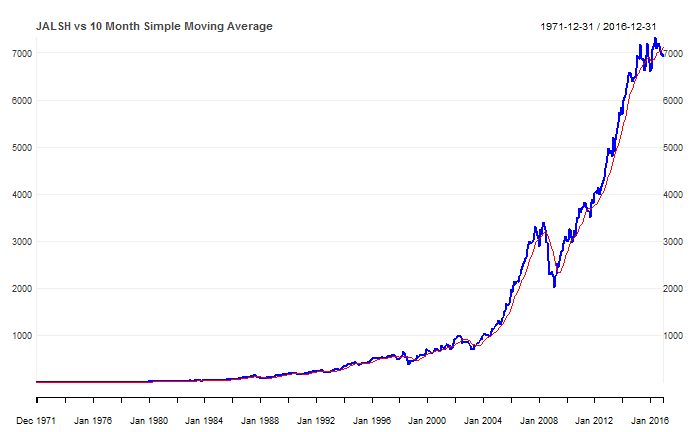

```r
myChart_Theme <- chart_theme() #Create a chart_theme
myChart_Theme$col$line.col <- "blue"
SMAperiod <- 10
chart_Series(Cl(JALSH),
  name = paste("JALSH vs 10 Month Simple Moving Average",sep = ""),
  theme=myChart_Theme,
  type = "line",
  subset = SubsetPeriod.Reporting,
  TA = 'add_SMA(n=SMAperiod, on=1, col="red")'
  )
```

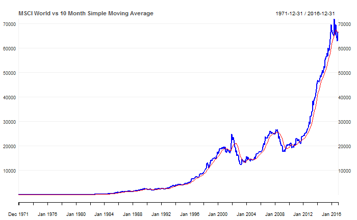

```r
chart_Series(Cl(MSCIWORLD),
  name = paste("MSCI World vs 10 Month Simple Moving Average",sep = ""),
  theme=myChart_Theme,
  type = "line",
  subset = SubsetPeriod.Reporting,
  TA = 'add_SMA(n=SMAperiod, on=1, col="red")'
  )
```

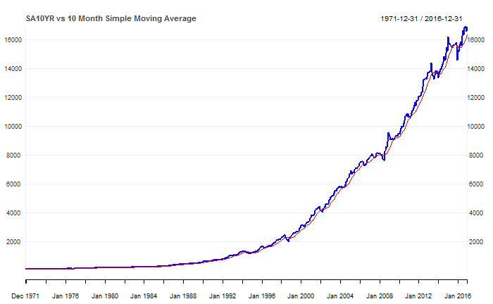

```r
chart_Series(Cl(SA10YR),
  name = paste("SA10YR vs 10 Month Simple Moving Average",sep = ""),
  theme=myChart_Theme,
  type = "line",
  subset = SubsetPeriod.Reporting,
  TA = 'add_SMA(n=SMAperiod, on=1, col="red")'
  )
```

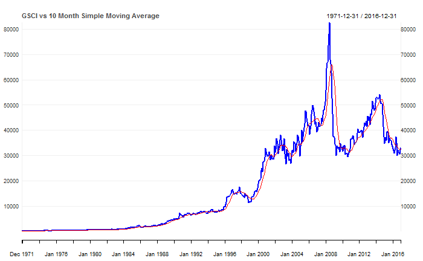

```r
chart_Series(Cl(GSCI),
  name = paste("GSCI vs 10 Month Simple Moving Average",sep = ""),
  theme=myChart_Theme,
  type = "line",
  subset = SubsetPeriod.Reporting,
  TA = 'add_SMA(n=SMAperiod, on=1, col="red")'
  )
```

```r
#change to other chart so can make it log?
```

#### Calculating returns

```r
#Import saved pricing data csv files as xts
getSymbols("TBILLYIELDS",
           src = "csv",
           dir="../Data/CSV files/SA Long Term/",
           col.names=c("Close"))
```

```
[1] "TBILLYIELDS"
```

```r
#load an additional library
library(dplyr)
#Create new all assets
AllAssets <- cbind.xts(Cl(JALSH),
                       Cl(MSCIWORLD),
                       Cl(SA10YR),
                       Cl(GSCI),
                       Cl(TBILLYIELDS))
AllAssets <- AllAssets[SubsetPeriod.Calculations]
#create dataframe - tidyverse not compatible with xts?
AllAssets.df <- data.frame(date=index(AllAssets), coredata(AllAssets)) #, row.names = index(AllAssets))
BuyBand <- 1.025
SellBand <- 1.00
#mutate new columns
AllAssets.df  <- mutate(AllAssets.df,
  "RF.ret" =  c(0,lag((TBILLYIELDS.Close/100)/12)[-1]),
  #is this right?
  "JALSH.ret" =  c(0,diff(JALSH.Close)/lag(JALSH.Close)[-1]),

  "JALSH.2m.SMA" =  rollmean(JALSH.Close,2,fill = 0,align = "right"),
  "JALSH.5m.SMA" =  rollmean(JALSH.Close,5,fill = 0,align = "right"),
  "JALSH.10m.SMA" =  rollmean(JALSH.Close,10,fill = 0,align = "right"),

  "JALSH.2m.signal" =  lag(ifelse(JALSH.Close>=JALSH.2m.SMA,1,0)),
  "JALSH.5m.signal" =  lag(ifelse(JALSH.Close>=JALSH.5m.SMA,1,0)),
  "JALSH.10m.signal" =  lag(ifelse(JALSH.Close>=JALSH.10m.SMA,1,0)),
  "JALSH.2m.signal.delayed" =  lag(ifelse(JALSH.Close>=JALSH.2m.SMA,ifelse(JALSH.2m.signal==1,1,0),0)),
  "JALSH.5m.signal.delayed" =  lag(ifelse(JALSH.Close>=JALSH.5m.SMA,ifelse(JALSH.5m.signal==1,1,0),0)),
  "JALSH.10m.signal.delayed" =  lag(ifelse(JALSH.Close>=JALSH.10m.SMA,ifelse(JALSH.10m.signal==1,1,0),0)),
  "JALSH.2m.timingret" = ifelse(JALSH.2m.signal == 1,JALSH.ret,RF.ret),
  "JALSH.5m.timingret" = ifelse(JALSH.5m.signal == 1,JALSH.ret,RF.ret),
  "JALSH.10m.timingret" = ifelse(JALSH.10m.signal == 1,JALSH.ret,RF.ret),
  "JALSH.2m.timingret.delayed" = ifelse(JALSH.2m.signal.delayed == 1,JALSH.ret,RF.ret),
  "JALSH.5m.timingret.delayed" = ifelse(JALSH.5m.signal.delayed == 1,JALSH.ret,RF.ret),
  "JALSH.10m.timingret.delayed" = ifelse(JALSH.10m.signal.delayed == 1,JALSH.ret,RF.ret),
  "JALSH.avg.timingret" = (JALSH.2m.timingret + JALSH.5m.timingret + JALSH.10m.timingret)/3,
  "JALSH.avg.signal" = (JALSH.2m.signal + JALSH.5m.signal + JALSH.10m.signal)/3,
  "JALSH.avg.timingret.delayed" = (JALSH.2m.timingret.delayed + JALSH.5m.timingret.delayed + JALSH.10m.timingret.delayed)/3,
  "JALSH.avg.signal.delayed" = (JALSH.2m.signal.delayed + JALSH.5m.signal.delayed + JALSH.10m.signal.delayed)/3,
  "JALSH.avg.combo" = (JALSH.avg.timingret + JALSH.avg.timingret.delayed)/2,
  "JALSH.avg.combo.signal" = (JALSH.avg.signal + JALSH.avg.signal.delayed)/2,
  "MSCIWORLD.ret" =  c(0,diff(MSCIWORLD.Close)/lag(MSCIWORLD.Close)[-1]),

  "MSCIWORLD.2m.SMA" =  rollmean(MSCIWORLD.Close,2,fill = 0,align = "right"),
  "MSCIWORLD.5m.SMA" =  rollmean(MSCIWORLD.Close,5,fill = 0,align = "right"),
  "MSCIWORLD.10m.SMA" =  rollmean(MSCIWORLD.Close,10,fill = 0,align = "right"),

  "MSCIWORLD.2m.signal" =  lag(ifelse(MSCIWORLD.Close>=MSCIWORLD.2m.SMA,1,0)),
  "MSCIWORLD.5m.signal" =  lag(ifelse(MSCIWORLD.Close>=MSCIWORLD.5m.SMA,1,0)),
  "MSCIWORLD.10m.signal" =  lag(ifelse(MSCIWORLD.Close>=MSCIWORLD.10m.SMA,1,0)),
  "MSCIWORLD.2m.signal.delayed" =  lag(ifelse(MSCIWORLD.Close>=MSCIWORLD.2m.SMA,ifelse(MSCIWORLD.2m.signal==1,1,0),0)),
  "MSCIWORLD.5m.signal.delayed" =  lag(ifelse(MSCIWORLD.Close>=MSCIWORLD.5m.SMA,ifelse(MSCIWORLD.5m.signal==1,1,0),0)),
  "MSCIWORLD.10m.signal.delayed" =  lag(ifelse(MSCIWORLD.Close>=MSCIWORLD.10m.SMA,ifelse(MSCIWORLD.10m.signal==1,1,0),0)),
  "MSCIWORLD.2m.timingret" = ifelse(MSCIWORLD.2m.signal == 1,MSCIWORLD.ret,RF.ret),
  "MSCIWORLD.5m.timingret" = ifelse(MSCIWORLD.5m.signal == 1,MSCIWORLD.ret,RF.ret),
  "MSCIWORLD.10m.timingret" = ifelse(MSCIWORLD.10m.signal == 1,MSCIWORLD.ret,RF.ret),
  "MSCIWORLD.2m.timingret.delayed" = ifelse(MSCIWORLD.2m.signal.delayed == 1,MSCIWORLD.ret,RF.ret),
  "MSCIWORLD.5m.timingret.delayed" = ifelse(MSCIWORLD.5m.signal.delayed == 1,MSCIWORLD.ret,RF.ret),
  "MSCIWORLD.10m.timingret.delayed" = ifelse(MSCIWORLD.10m.signal.delayed == 1,MSCIWORLD.ret,RF.ret),

  "MSCIWORLD.avg.timingret" = (MSCIWORLD.2m.timingret + MSCIWORLD.5m.timingret + MSCIWORLD.10m.timingret)/3,
  "MSCIWORLD.avg.signal" = (MSCIWORLD.2m.signal + MSCIWORLD.5m.signal + MSCIWORLD.10m.signal)/3,
  "MSCIWORLD.avg.timingret.delayed" = (MSCIWORLD.2m.timingret.delayed + MSCIWORLD.5m.timingret.delayed + MSCIWORLD.10m.timingret.delayed)/3,
  "MSCIWORLD.avg.signal.delayed" = (MSCIWORLD.2m.signal.delayed + MSCIWORLD.5m.signal.delayed + MSCIWORLD.10m.signal.delayed)/3,
  "MSCIWORLD.avg.combo" = (MSCIWORLD.avg.timingret + MSCIWORLD.avg.timingret.delayed)/2,
  "MSCIWORLD.avg.combo.signal" = (MSCIWORLD.avg.signal + MSCIWORLD.avg.signal.delayed)/2,

  "MSCIWORLD.avg.combo" = (MSCIWORLD.avg.timingret + MSCIWORLD.avg.timingret.delayed)/2,
  "MSCIWORLD.avg.combo.signal" = (MSCIWORLD.avg.signal + MSCIWORLD.avg.signal.delayed)/2,

  "SA10YR.ret" =  c(0,diff(SA10YR.Close)/lag(SA10YR.Close)[-1]),

  "SA10YR.2m.SMA" =  rollmean(SA10YR.Close,2,fill = 0,align = "right"),
  "SA10YR.5m.SMA" =  rollmean(SA10YR.Close,5,fill = 0,align = "right"),
  "SA10YR.10m.SMA" =  rollmean(SA10YR.Close,10,fill = 0,align = "right"),

  "SA10YR.2m.signal" =  lag(ifelse(SA10YR.Close>=SA10YR.2m.SMA,1,0)),
  "SA10YR.5m.signal" =  lag(ifelse(SA10YR.Close>=SA10YR.5m.SMA,1,0)),
  "SA10YR.10m.signal" =  lag(ifelse(SA10YR.Close>=SA10YR.10m.SMA,1,0)),
  "SA10YR.2m.signal.delayed" =  lag(ifelse(SA10YR.Close>=SA10YR.2m.SMA,ifelse(SA10YR.2m.signal==1,1,0),0)),
  "SA10YR.5m.signal.delayed" =  lag(ifelse(SA10YR.Close>=SA10YR.5m.SMA,ifelse(SA10YR.5m.signal==1,1,0),0)),
  "SA10YR.10m.signal.delayed" =  lag(ifelse(SA10YR.Close>=SA10YR.10m.SMA,ifelse(SA10YR.10m.signal==1,1,0),0)),

  "SA10YR.2m.timingret" = ifelse(SA10YR.2m.signal == 1,SA10YR.ret,RF.ret),
  "SA10YR.5m.timingret" = ifelse(SA10YR.5m.signal == 1,SA10YR.ret,RF.ret),
  "SA10YR.10m.timingret" = ifelse(SA10YR.10m.signal == 1,SA10YR.ret,RF.ret),
  "SA10YR.2m.timingret.delayed" = ifelse(SA10YR.2m.signal.delayed == 1,SA10YR.ret,RF.ret),
  "SA10YR.5m.timingret.delayed" = ifelse(SA10YR.5m.signal.delayed == 1,SA10YR.ret,RF.ret),
  "SA10YR.10m.timingret.delayed" = ifelse(SA10YR.10m.signal.delayed == 1,SA10YR.ret,RF.ret),
```

```r
  "SA10YR.avg.timingret" = (SA10YR.2m.timingret + SA10YR.5m.timingret + SA10YR.10m.timingret)/3,
  "SA10YR.avg.signal" = (SA10YR.2m.signal + SA10YR.5m.signal + SA10YR.10m.signal)/3,
  "SA10YR.avg.timingret.delayed" = (SA10YR.2m.timingret.delayed + SA10YR.5m.timingret.delayed + SA10YR.10m.timingret.delayed)/3,
  "SA10YR.avg.signal.delayed" = (SA10YR.2m.signal.delayed + SA10YR.5m.signal.delayed + SA10YR.10m.signal.delayed)/3,
  "SA10YR.avg.combo" = (SA10YR.avg.timingret + SA10YR.avg.timingret.delayed)/2,
  "SA10YR.avg.combo.signal" = (SA10YR.avg.signal + SA10YR.avg.signal.delayed)/2,
  "GSCI.ret" =  c(0,diff(GSCI.Close)/lag(GSCI.Close)[-1]),

  "GSCI.2m.SMA" =  rollmean(GSCI.Close,2,fill = 0,align = "right"),
  "GSCI.5m.SMA" =  rollmean(GSCI.Close,5,fill = 0,align = "right"),
  "GSCI.10m.SMA" =  rollmean(GSCI.Close,10,fill = 0,align = "right"),

  "GSCI.2m.signal" =  lag(ifelse(GSCI.Close>=GSCI.2m.SMA,1,0)),
  "GSCI.5m.signal" =  lag(ifelse(GSCI.Close>=GSCI.5m.SMA,1,0)),
  "GSCI.10m.signal" =  lag(ifelse(GSCI.Close>=GSCI.10m.SMA,1,0)),
  "GSCI.2m.signal.delayed" =  lag(ifelse(GSCI.Close>=GSCI.2m.SMA,ifelse(GSCI.2m.signal==1,1,0),0)),
  "GSCI.5m.signal.delayed" =  lag(ifelse(GSCI.Close>=GSCI.5m.SMA,ifelse(GSCI.5m.signal==1,1,0),0)),
  "GSCI.10m.signal.delayed" =  lag(ifelse(GSCI.Close>=GSCI.10m.SMA,ifelse(GSCI.10m.signal==1,1,0),0)),

  "GSCI.2m.timingret" = ifelse(GSCI.2m.signal == 1,GSCI.ret,RF.ret),
  "GSCI.5m.timingret" = ifelse(GSCI.5m.signal == 1,GSCI.ret,RF.ret),
  "GSCI.10m.timingret" = ifelse(GSCI.10m.signal == 1,GSCI.ret,RF.ret),
  "GSCI.2m.timingret.delayed" = ifelse(GSCI.2m.signal.delayed == 1,GSCI.ret,RF.ret),
  "GSCI.5m.timingret.delayed" = ifelse(GSCI.5m.signal.delayed == 1,GSCI.ret,RF.ret),
  "GSCI.10m.timingret.delayed" = ifelse(GSCI.10m.signal.delayed == 1,GSCI.ret,RF.ret),
  "GSCI.avg.timingret" = (GSCI.2m.timingret + GSCI.5m.timingret + GSCI.10m.timingret)/3,
  "GSCI.avg.signal" = (GSCI.2m.signal + GSCI.5m.signal + GSCI.10m.signal)/3,
  "GSCI.avg.timingret.delayed" = (GSCI.2m.timingret.delayed + GSCI.5m.timingret.delayed + GSCI.10m.timingret.delayed)/3,
  "GSCI.avg.signal.delayed" = (GSCI.2m.signal.delayed + GSCI.5m.signal.delayed + GSCI.10m.signal.delayed)/3,
  "GSCI.avg.combo" = (GSCI.avg.timingret + GSCI.avg.timingret.delayed)/2,
  "GSCI.avg.combo.signal" = (GSCI.avg.signal + GSCI.avg.signal.delayed)/2,
  "JALSH.2m.signal.band" =  ifelse(row_number()<=2,0,
                                    lag(ifelse(JALSH.Close>=(BuyBand*JALSH.2m.SMA),1,
                                        ifelse(JALSH.Close<(SellBand*JALSH.2m.SMA),0,2)))),
  "JALSH.5m.signal.band" =  ifelse(row_number()<=5,0,
                                    lag(ifelse(JALSH.Close>=(BuyBand*JALSH.5m.SMA),1,
                                        ifelse(JALSH.Close<(SellBand*JALSH.5m.SMA),0,2)))),
  "JALSH.10m.signal.band" =  ifelse(row_number()<=10,0,
                                    lag(ifelse(JALSH.Close>=(BuyBand*JALSH.10m.SMA),1,
                                        ifelse(JALSH.Close<(SellBand*JALSH.10m.SMA),0,2)))),

  "MSCIWORLD.2m.signal.band" =  ifelse(row_number()<=2,0,
                                    lag(ifelse(MSCIWORLD.Close>=(BuyBand*MSCIWORLD.2m.SMA),1,
                                        ifelse(MSCIWORLD.Close<(SellBand*MSCIWORLD.2m.SMA),0,2)))),
  "MSCIWORLD.5m.signal.band" =  ifelse(row_number()<=5,0,
                                    lag(ifelse(MSCIWORLD.Close>=(BuyBand*MSCIWORLD.5m.SMA),1,
                                        ifelse(MSCIWORLD.Close<(SellBand*MSCIWORLD.5m.SMA),0,2)))),
  "MSCIWORLD.10m.signal.band" =  ifelse(row_number()<=10,0,
                                    lag(ifelse(MSCIWORLD.Close>=(BuyBand*MSCIWORLD.10m.SMA),1,
                                        ifelse(MSCIWORLD.Close<(SellBand*MSCIWORLD.10m.SMA),0,2)))),

  "SA10YR.2m.signal.band" =  ifelse(row_number()<=2,0,
                                    lag(ifelse(SA10YR.Close>=(BuyBand*SA10YR.2m.SMA),1,
                                        ifelse(SA10YR.Close<(SellBand*SA10YR.2m.SMA),0,2)))),
  "SA10YR.5m.signal.band" =  ifelse(row_number()<=5,0,
                                    lag(ifelse(SA10YR.Close>=(BuyBand*SA10YR.5m.SMA),1,
                                        ifelse(SA10YR.Close<(SellBand*SA10YR.5m.SMA),0,2)))),
  "SA10YR.10m.signal.band" =  ifelse(row_number()<=10,0,
                                    lag(ifelse(SA10YR.Close>=(BuyBand*SA10YR.10m.SMA),1,
                                        ifelse(SA10YR.Close<(SellBand*SA10YR.10m.SMA),0,2)))),
  "GSCI.2m.signal.band" =  ifelse(row_number()<=2,0,
                                    lag(ifelse(GSCI.Close>=(BuyBand*GSCI.2m.SMA),1,
                                        ifelse(GSCI.Close<(SellBand*GSCI.2m.SMA),0,2)))),
  "GSCI.5m.signal.band" =  ifelse(row_number()<=5,0,
                                    lag(ifelse(GSCI.Close>=(BuyBand*GSCI.5m.SMA),1,
                                        ifelse(GSCI.Close<(SellBand*GSCI.5m.SMA),0,2)))),
  "GSCI.10m.signal.band" =  ifelse(row_number()<=10,0,
                                    lag(ifelse(GSCI.Close>=(BuyBand*GSCI.10m.SMA),1,
                                        ifelse(GSCI.Close<(SellBand*GSCI.10m.SMA),0,2)))),
  "BuyandHold.ret" = (JALSH.ret + MSCIWORLD.ret + SA10YR.ret + GSCI.ret)/4,

  "Timing.ret" = (JALSH.10m.timingret + MSCIWORLD.10m.timingret + SA10YR.10m.timingret + GSCI.10m.timingret)/4,
  "Timing.signal" = (JALSH.10m.signal + MSCIWORLD.10m.signal + SA10YR.10m.signal + GSCI.10m.signal)/4,

  "DelayedTiming.ret" = (JALSH.10m.timingret.delayed + MSCIWORLD.10m.timingret.delayed + SA10YR.10m.timingret.delayed + GSCI.10m.timingret.delayed)/4,
  "DelayedTiming.signal" = (JALSH.10m.signal.delayed + MSCIWORLD.10m.signal.delayed + SA10YR.10m.signal.delayed + GSCI.10m.signal.delayed)/4,

  "Avg.Timing.ret" = (JALSH.avg.timingret + MSCIWORLD.avg.timingret + SA10YR.avg.timingret + GSCI.avg.timingret)/4,
  "Avg.Timing.signal" = (JALSH.avg.signal + MSCIWORLD.avg.signal + SA10YR.avg.signal + GSCI.avg.signal)/4,
```

```r
  "Avg.DelayedTiming.ret" = (JALSH.avg.timingret.delayed + MSCIWORLD.avg.timingret.delayed +
                            SA10YR.avg.timingret.delayed + GSCI.avg.timingret.delayed)/4,
  "Avg.DelayedTiming.signal" = (JALSH.avg.signal.delayed + MSCIWORLD.avg.signal.delayed +
                            SA10YR.avg.signal.delayed + GSCI.avg.signal.delayed)/4,

  "Avg.Combo.ret" = (JALSH.avg.combo + MSCIWORLD.avg.combo +
                            SA10YR.avg.combo + GSCI.avg.combo)/4,
  "Avg.Combo.signal" = (JALSH.avg.combo.signal + MSCIWORLD.avg.combo.signal +
                            SA10YR.avg.combo.signal + GSCI.avg.combo.signal)/4

  )
# update signal for band strategy
for(i in 1:length(AllAssets.df$JALSH.10m.signal.band)){
  if(AllAssets.df$JALSH.2m.signal.band[i] == 2){AllAssets.df$JALSH.2m.signal.band[i] = AllAssets.df$JALSH.2m.signal.band[i-1]}
  if(AllAssets.df$JALSH.5m.signal.band[i] == 2){AllAssets.df$JALSH.5m.signal.band[i] = AllAssets.df$JALSH.5m.signal.band[i-1]}
  if(AllAssets.df$JALSH.10m.signal.band[i] == 2){AllAssets.df$JALSH.10m.signal.band[i] = AllAssets.df$JALSH.10m.signal.band[i-1]}

  if(AllAssets.df$MSCIWORLD.2m.signal.band[i] == 2){AllAssets.df$MSCIWORLD.2m.signal.band[i] = AllAssets.df$MSCIWORLD.2m.signal.band[i-1]}
  if(AllAssets.df$MSCIWORLD.5m.signal.band[i] == 2){AllAssets.df$MSCIWORLD.5m.signal.band[i] = AllAssets.df$MSCIWORLD.5m.signal.band[i-1]}
  if(AllAssets.df$MSCIWORLD.10m.signal.band[i] == 2){AllAssets.df$MSCIWORLD.10m.signal.band[i] = AllAssets.df$MSCIWORLD.10m.signal.band[i-1]}

  if(AllAssets.df$SA10YR.2m.signal.band[i] == 2){AllAssets.df$SA10YR.2m.signal.band[i] = AllAssets.df$SA10YR.2m.signal.band[i-1]}
  if(AllAssets.df$SA10YR.5m.signal.band[i] == 2){AllAssets.df$SA10YR.5m.signal.band[i] = AllAssets.df$SA10YR.5m.signal.band[i-1]}
  if(AllAssets.df$SA10YR.10m.signal.band[i] == 2){AllAssets.df$SA10YR.10m.signal.band[i] = AllAssets.df$SA10YR.10m.signal.band[i-1]}

  if(AllAssets.df$GSCI.2m.signal.band[i] == 2){AllAssets.df$GSCI.2m.signal.band[i] = AllAssets.df$GSCI.2m.signal.band[i-1]}
  if(AllAssets.df$GSCI.5m.signal.band[i] == 2){AllAssets.df$GSCI.5m.signal.band[i] = AllAssets.df$GSCI.5m.signal.band[i-1]}
  if(AllAssets.df$GSCI.10m.signal.band[i] == 2){AllAssets.df$GSCI.10m.signal.band[i] = AllAssets.df$GSCI.10m.signal.band[i-1]}
}
#calculat returns for band strategy
AllAssets.df  <- mutate(AllAssets.df,
  "JALSH.2m.timingret.band" = ifelse(JALSH.2m.signal.band == 1,JALSH.ret,RF.ret),
  "JALSH.5m.timingret.band" = ifelse(JALSH.5m.signal.band == 1,JALSH.ret,RF.ret),
  "JALSH.10m.timingret.band" = ifelse(JALSH.10m.signal.band == 1,JALSH.ret,RF.ret),

  "JALSH.avg.timingret.band" = (JALSH.2m.timingret.band + JALSH.5m.timingret.band + JALSH.10m.timingret.band)/3,
  "JALSH.avg.signal.band" = (JALSH.2m.signal.band + JALSH.5m.signal.band + JALSH.10m.signal.band)/3,
  "JALSH.avg.combo.band" = (JALSH.avg.timingret + JALSH.avg.timingret.delayed  + JALSH.avg.timingret.band)/3,
  "JALSH.avg.combo.band.signal" = (JALSH.avg.signal + JALSH.avg.signal.delayed + JALSH.avg.signal.band)/3,
  "MSCIWORLD.2m.timingret.band" = ifelse(MSCIWORLD.2m.signal.band == 1,MSCIWORLD.ret,RF.ret),
  "MSCIWORLD.5m.timingret.band" = ifelse(MSCIWORLD.5m.signal.band == 1,MSCIWORLD.ret,RF.ret),
  "MSCIWORLD.10m.timingret.band" = ifelse(MSCIWORLD.10m.signal.band == 1,MSCIWORLD.ret,RF.ret),

  "MSCIWORLD.avg.timingret.band" = (MSCIWORLD.2m.timingret.band + MSCIWORLD.5m.timingret.band + MSCIWORLD.10m.timingret.band)/3,
  "MSCIWORLD.avg.signal.band" = (MSCIWORLD.2m.signal.band + MSCIWORLD.5m.signal.band + MSCIWORLD.10m.signal.band)/3,
  "MSCIWORLD.avg.combo.band" = (MSCIWORLD.avg.timingret + MSCIWORLD.avg.timingret.delayed  + MSCIWORLD.avg.timingret.band)/3,
  "MSCIWORLD.avg.combo.band.signal" = (MSCIWORLD.avg.signal + MSCIWORLD.avg.signal.delayed + MSCIWORLD.avg.signal.band)/3,

  "SA10YR.2m.timingret.band" = ifelse(SA10YR.2m.signal.band == 1,SA10YR.ret,RF.ret),
  "SA10YR.5m.timingret.band" = ifelse(SA10YR.5m.signal.band == 1,SA10YR.ret,RF.ret),
  "SA10YR.10m.timingret.band" = ifelse(SA10YR.10m.signal.band == 1,SA10YR.ret,RF.ret),

  "SA10YR.avg.timingret.band" = (SA10YR.2m.timingret.band + SA10YR.5m.timingret.band + SA10YR.10m.timingret.band)/3,
  "SA10YR.avg.signal.band" = (SA10YR.2m.signal.band + SA10YR.5m.signal.band + SA10YR.10m.signal.band)/3,
  "SA10YR.avg.combo.band" = (SA10YR.avg.timingret + SA10YR.avg.timingret.delayed  + SA10YR.avg.timingret.band)/3,
  "SA10YR.avg.combo.band.signal" = (SA10YR.avg.signal + SA10YR.avg.signal.delayed + SA10YR.avg.signal.band)/3,

  "GSCI.2m.timingret.band" = ifelse(GSCI.2m.signal.band == 1,GSCI.ret,RF.ret),
  "GSCI.5m.timingret.band" = ifelse(GSCI.5m.signal.band == 1,GSCI.ret,RF.ret),
  "GSCI.10m.timingret.band" = ifelse(GSCI.10m.signal.band == 1,GSCI.ret,RF.ret),

  "GSCI.avg.timingret.band" = (GSCI.2m.timingret.band + GSCI.5m.timingret.band + GSCI.10m.timingret.band)/3,
  "GSCI.avg.signal.band" = (GSCI.2m.signal.band + GSCI.5m.signal.band + GSCI.10m.signal.band)/3,
  "GSCI.avg.combo.band" = (GSCI.avg.timingret + GSCI.avg.timingret.delayed  + GSCI.avg.timingret.band)/3,
  "GSCI.avg.combo.band.signal" = (GSCI.avg.signal + GSCI.avg.signal.delayed + GSCI.avg.signal.band)/3,
  "BandTiming.ret" = (JALSH.10m.timingret.band + MSCIWORLD.10m.timingret.band
                         + SA10YR.10m.timingret.band + GSCI.10m.timingret.band)/4,
  "BandTiming.signal" = (JALSH.10m.signal.band + MSCIWORLD.10m.signal.band
                            + SA10YR.10m.signal.band + GSCI.10m.signal.band)/4,
  "Avg.BandTiming.ret" = (JALSH.avg.timingret.band + MSCIWORLD.avg.timingret.band +
                            SA10YR.avg.timingret.band + GSCI.avg.timingret.band)/4,
  "Avg.BandTiming.signal" = (JALSH.avg.signal.band + MSCIWORLD.avg.signal.band +
                            SA10YR.avg.signal.band + GSCI.avg.signal.band)/4,
  "Avg.Combo.Band.ret" = (JALSH.avg.combo.band + MSCIWORLD.avg.combo.band +
                            SA10YR.avg.combo.band + GSCI.avg.combo.band)/4,
  "Avg.Combo.Band.signal" = (JALSH.avg.combo.band.signal + MSCIWORLD.avg.combo.band.signal +
                            SA10YR.avg.combo.band.signal + GSCI.avg.combo.band.signal)/4
  )
rownames(AllAssets.df) <- index(AllAssets)
#Create xts of calculations to analyse performance
AllAssets.xts <- xts(AllAssets.df[,-1], order.by = AllAssets.df$date)
#detach the packagae dplyr as it isn't compatible with other packages?
detach(package:dplyr)
```

#### Individual Asset Class Strategy Comparisons and Stats

```r
#for calculating the sharpe ratio later
Rf.ret <- Return.calculate(TBILLYIELDS)[-1,]
Rf.ret <- Rf.ret[SubsetPeriod.Reporting]
FormatMultiplier <- 100
Strategies <- c("B&H","Timing","Timing Delayed","Timing Band","Multi Timing","Multi Strat")
PerformanceMeasures <- c("CAGR","Volatility","Skew","Kurtosis","Inflation CAGR","% in the Market","% positive Months","Best Month","Worst Month","Max Drawdown","Max Drawdown / CAGR",paste("Sharpe Ratio (",round(100*Return.annualized(Return.calculate(TBILLS)[SubsetPeriod.Reporting]),2),"%)", sep = ""),"Sortino Ratio","MAR Ratio","Ulcer Index")
```

#### JALSH

[output not shown]

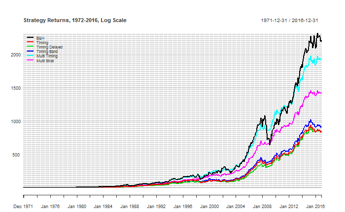

```r
Returns <- cbind.xts(AllAssets.xts$JALSH.ret,
                     AllAssets.xts$JALSH.10m.timingret,
                     AllAssets.xts$JALSH.10m.timingret.delayed,
                     AllAssets.xts$JALSH.10m.timingret.band,
                     AllAssets.xts$JALSH.avg.timingret,
                     AllAssets.xts$JALSH.avg.combo.band)[SubsetPeriod.Reporting]
colnames(Returns) <- Strategies
chart.CumReturns(Returns, wealth.index = TRUE,
  main = "Strategy Returns, 1972-2016, Log Scale",
  #colorset = c(4,2,3,5,6),
  legend.loc = "topleft",
  date.format = "%Y", ylab = "", ylog = TRUE)
```

[output not shown]

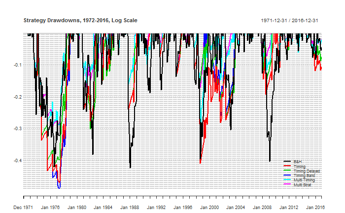

```r
chart.Drawdown(Returns,#[,-1], to exclude B&H
  main = "Strategy Drawdowns, 1972-2016, Log Scale",
  date.format = "%Y",
  #colorset = c(4,2,3,5,6),
  ylab = "Drawdown", legend.loc = "bottomright", major.ticks = "years",  minor.ticks = FALSE)
```

```r
TimeInMarket <- c(nrow(AllAssets.xts[SubsetPeriod.Reporting]),
                  sum(AllAssets.xts$JALSH.10m.signal[SubsetPeriod.Reporting]),
                  sum(AllAssets.xts$JALSH.10m.signal.delayed[SubsetPeriod.Reporting]),
                  sum(AllAssets.xts$JALSH.10m.signal.band[SubsetPeriod.Reporting]),
                  sum(AllAssets.xts$JALSH.avg.signal[SubsetPeriod.Reporting]),
                  sum(AllAssets.xts$JALSH.avg.combo.signal[SubsetPeriod.Reporting]))/nrow(AllAssets.xts[SubsetPeriod.Reporting])
FullStats <- rbind(Return.annualized(Returns,scale = 12)*FormatMultiplier,
                   StdDev.annualized(Returns,scale = 12)*FormatMultiplier,
                   skewness(Returns),
                   kurtosis(Returns),
                   100*c(Return.annualized(AllAssets.ret$SACPI[SubsetPeriod.Reporting],scale = 12)),
                   TimeInMarket*FormatMultiplier,
                   apply(Returns, 2, function(x) length(x[x>0]))/nrow(Returns)*FormatMultiplier,
                   apply(Returns, 2, function(x) max(x, na.rm = TRUE))*FormatMultiplier,
                   apply(Returns, 2, function(x) min(x, na.rm = TRUE))*FormatMultiplier,
                   maxDrawdown(Returns,scale = 12,invert = FALSE)*FormatMultiplier,
                   -maxDrawdown(Returns,scale = 12,invert = FALSE)/Return.annualized(Returns,scale = 12),
                   SharpeRatio.annualized(Returns,Rf = AllAssets.ret$TBILLS[SubsetPeriod.Reporting]),
                   SortinoRatio(Returns, scale = 12), #what MAR?
                   CalmarRatio(Returns, scale = 12),
                   UlcerIndex(Returns)*FormatMultiplier)
colnames(FullStats) <- Strategies
rownames(FullStats) <- PerformanceMeasures
round(FullStats,2)
```

|  | B&H | Timing | Timing Delayed | Timing Band | Multi Timing | Multi Strat |
| --- | --- | --- | --- | --- | --- | --- |
| CAGR | 18.63 | 16.13 | 16.12 | 16.34 | 18.29 | 17.50 |
| Volatility | 20.99 | 17.26 | 15.96 | 16.48 | 14.90 | 13.36 |
| Skew | -0.45 | -0.66 | -0.32 | -0.28 | 0.01 | 0.20 |
| Kurtosis | 1.70 | 4.40 | 3.04 | 2.52 | 2.57 | 2.66 |
| Inflation CAGR | 9.48 | 9.48 | 9.48 | 9.48 | 9.48 | 9.48 |
| % in the Market | 100.00 | 75.42 | 69.32 | 73.75 | 69.38 | 62.88 |
| % positive Months | 61.92 | 71.53 | 74.12 | 71.90 | 69.87 | 71.16 |
| Best Month | 18.28 | 17.70 | 17.70 | 17.70 | 17.70 | 17.18 |
| Worst Month | -29.58 | -29.58 | -23.41 | -23.41 | -19.19 | -15.37 |
| Max Drawdown | -42.45 | -47.02 | -42.34 | -48.98 | -29.30 | -29.16 |

[output cut: 5 more lines]

```r
write.table(round(FullStats,4), "clipboard", sep="\t", col.names=NA)
```

#### MSCIWORLD

[output not shown]

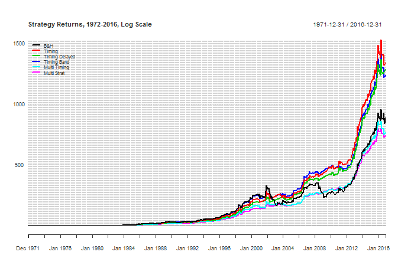

```r
Returns <- cbind.xts(AllAssets.xts$MSCIWORLD.ret,
                     AllAssets.xts$MSCIWORLD.10m.timingret,
                     AllAssets.xts$MSCIWORLD.10m.timingret.delayed,
                     AllAssets.xts$MSCIWORLD.10m.timingret.band,
                     AllAssets.xts$MSCIWORLD.avg.timingret,
                     AllAssets.xts$MSCIWORLD.avg.combo.band)[SubsetPeriod.Reporting]
colnames(Returns) <- Strategies
chart.CumReturns(Returns, wealth.index = TRUE,
  main = "Strategy Returns, 1972-2016, Log Scale",
  #colorset = c(4,2,3,5,6),
  legend.loc = "topleft",
  date.format = "%Y", ylab = "", ylog = TRUE)
```

[output not shown]

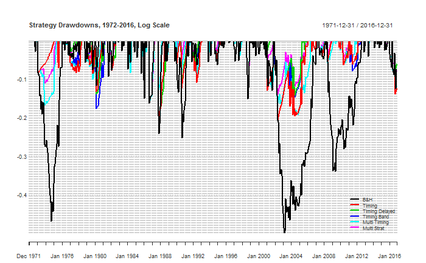

```r
chart.Drawdown(Returns,#[,-1], to exclude B&H
  main = "Strategy Drawdowns, 1972-2016, Log Scale",
  date.format = "%Y",
  #colorset = c(4,2,3,5,6),
  ylab = "Drawdown", legend.loc = "bottomright", major.ticks = "years",  minor.ticks = FALSE)
```

```r
TimeInMarket <- c(nrow(AllAssets.xts[SubsetPeriod.Reporting]),
                  sum(AllAssets.xts$MSCIWORLD.10m.signal[SubsetPeriod.Reporting]),
                  sum(AllAssets.xts$MSCIWORLD.10m.signal.delayed[SubsetPeriod.Reporting]),
                  sum(AllAssets.xts$MSCIWORLD.10m.signal.band[SubsetPeriod.Reporting]),
                  sum(AllAssets.xts$MSCIWORLD.avg.signal[SubsetPeriod.Reporting]),
                  sum(AllAssets.xts$MSCIWORLD.avg.combo.band.signal[SubsetPeriod.Reporting]))/nrow(AllAssets.xts[SubsetPeriod.Reporting])
FullStats <- rbind(Return.annualized(Returns,scale = 12)*FormatMultiplier,
                   StdDev.annualized(Returns,scale = 12)*FormatMultiplier,
                   skewness(Returns),
                   kurtosis(Returns),
                   100*c(Return.annualized(AllAssets.ret$SACPI[SubsetPeriod.Reporting],scale = 12)),
                   TimeInMarket*FormatMultiplier,
                   apply(Returns, 2, function(x) length(x[x>0]))/nrow(Returns)*FormatMultiplier,
                   apply(Returns, 2, function(x) max(x, na.rm = TRUE))*FormatMultiplier,
                   apply(Returns, 2, function(x) min(x, na.rm = TRUE))*FormatMultiplier,
                   maxDrawdown(Returns,scale = 12,invert = FALSE)*FormatMultiplier,
                   -maxDrawdown(Returns,scale = 12,invert = FALSE)/Return.annualized(Returns,scale = 12),
                   SharpeRatio.annualized(Returns,Rf = AllAssets.ret$TBILLS[SubsetPeriod.Reporting]),
                   SortinoRatio(Returns, scale = 12), #what MAR?
                   CalmarRatio(Returns, scale = 12),
                   UlcerIndex(Returns)*FormatMultiplier)
colnames(FullStats) <- Strategies
rownames(FullStats) <- PerformanceMeasures
round(FullStats,2)
```

|  | B&H | Timing | Timing Delayed | Timing Band | Multi Timing | Multi Strat |
| --- | --- | --- | --- | --- | --- | --- |
| CAGR | 16.25 | 17.33 | 17.22 | 17.12 | 15.86 | 15.79 |
| Volatility | 17.57 | 15.07 | 14.55 | 14.62 | 13.53 | 12.28 |
| Skew | 0.40 | 0.69 | 0.78 | 0.74 | 0.88 | 1.14 |
| Kurtosis | 2.94 | 5.86 | 6.83 | 6.62 | 7.33 | 10.45 |
| Inflation CAGR | 9.48 | 9.48 | 9.48 | 9.48 | 9.48 | 9.48 |
| % in the Market | 100.00 | 77.45 | 71.90 | 73.20 | 70.92 | 61.72 |
| % positive Months | 62.85 | 73.57 | 75.79 | 75.60 | 71.72 | 74.49 |
| Best Month | 29.19 | 29.19 | 29.19 | 29.19 | 29.19 | 29.19 |
| Worst Month | -19.43 | -19.43 | -19.43 | -19.43 | -16.09 | -16.09 |
| Max Drawdown | -49.90 | -20.54 | -20.54 | -20.54 | -19.17 | -16.09 |

[output cut: 5 more lines]

```r
write.table(round(FullStats,4), "clipboard", sep="\t", col.names=NA)
```

#### SA10YR

[output not shown]

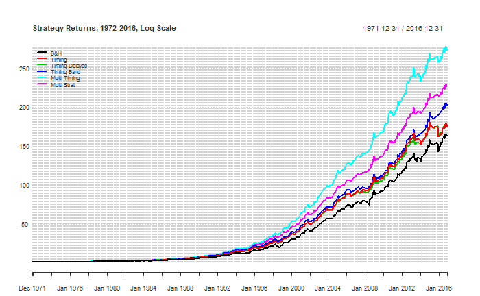

```r
Returns <- cbind.xts(AllAssets.xts$SA10YR.ret,
                     AllAssets.xts$SA10YR.10m.timingret,
                     AllAssets.xts$SA10YR.10m.timingret.delayed,
                     AllAssets.xts$SA10YR.10m.timingret.band,
                     AllAssets.xts$SA10YR.avg.timingret,
                     AllAssets.xts$SA10YR.avg.combo.band)[SubsetPeriod.Reporting]
colnames(Returns) <- Strategies
chart.CumReturns(Returns, wealth.index = TRUE,
  main = "Strategy Returns, 1972-2016, Log Scale",
  #colorset = c(4,2,3,5,6),
  legend.loc = "topleft",
  date.format = "%Y", ylab = "", ylog = TRUE)
```

[output not shown]

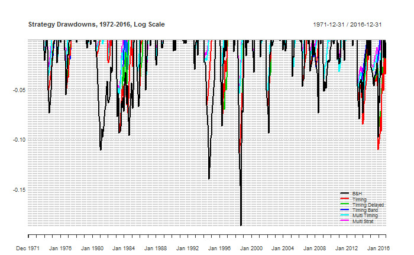

```r
chart.Drawdown(Returns,#[,-1], to exclude B&H
  main = "Strategy Drawdowns, 1972-2016, Log Scale",
  date.format = "%Y",
  #colorset = c(4,2,3,5,6),
  ylab = "Drawdown", legend.loc = "bottomright", major.ticks = "years",  minor.ticks = FALSE)
```

```r
TimeInMarket <- c(nrow(AllAssets.xts[SubsetPeriod.Reporting]),
                  sum(AllAssets.xts$SA10YR.10m.signal[SubsetPeriod.Reporting]),
                  sum(AllAssets.xts$SA10YR.10m.signal.delayed[SubsetPeriod.Reporting]),
                  sum(AllAssets.xts$SA10YR.10m.signal.bandd[SubsetPeriod.Reporting]),
                  sum(AllAssets.xts$SA10YR.avg.signal[SubsetPeriod.Reporting]),
                  sum(AllAssets.xts$SA10YR.avg.combo.band.signal[SubsetPeriod.Reporting]))/nrow(AllAssets.xts[SubsetPeriod.Reporting])
FullStats <- rbind(Return.annualized(Returns,scale = 12)*FormatMultiplier,
                   StdDev.annualized(Returns,scale = 12)*FormatMultiplier,
                   skewness(Returns),
                   kurtosis(Returns),
                   100*c(Return.annualized(AllAssets.ret$SACPI[SubsetPeriod.Reporting],scale = 12)),
                   TimeInMarket*FormatMultiplier,
                   apply(Returns, 2, function(x) length(x[x>0]))/nrow(Returns)*FormatMultiplier,
                   apply(Returns, 2, function(x) max(x, na.rm = TRUE))*FormatMultiplier,
                   apply(Returns, 2, function(x) min(x, na.rm = TRUE))*FormatMultiplier,
                   maxDrawdown(Returns,scale = 12,invert = FALSE)*FormatMultiplier,
                   -maxDrawdown(Returns,scale = 12,invert = FALSE)/Return.annualized(Returns,scale = 12),
                   SharpeRatio.annualized(Returns,Rf = AllAssets.ret$TBILLS[SubsetPeriod.Reporting]),
                   SortinoRatio(Returns, scale = 12), #what MAR?
                   CalmarRatio(Returns, scale = 12),
                   UlcerIndex(Returns)*FormatMultiplier)
colnames(FullStats) <- Strategies
rownames(FullStats) <- PerformanceMeasures
round(FullStats,2)
```

|  | B&H | Timing | Timing Delayed | Timing Band | Multi Timing | Multi Strat |
| --- | --- | --- | --- | --- | --- | --- |
| CAGR | 12.00 | 12.19 | 12.20 | 12.53 | 13.28 | 12.80 |
| Volatility | 7.35 | 6.62 | 6.50 | 6.32 | 5.93 | 5.27 |
| Skew | 0.20 | 0.05 | 0.06 | 0.17 | 0.44 | 0.47 |
| Kurtosis | 1.82 | 2.21 | 2.48 | 2.48 | 2.71 | 3.64 |
| Inflation CAGR | 9.48 | 9.48 | 9.48 | 9.48 | 9.48 | 9.48 |
| % in the Market | 100.00 | 87.43 | 83.36 | 0.00 | 80.28 | 67.53 |
| % positive Months | 73.57 | 77.82 | 78.93 | 80.22 | 80.96 | 84.47 |
| Best Month | 10.14 | 9.09 | 9.09 | 9.09 | 9.09 | 9.09 |
| Worst Month | -6.67 | -6.67 | -6.67 | -5.14 | -5.03 | -5.03 |
| Max Drawdown | -18.63 | -11.35 | -11.35 | -11.35 | -7.06 | -6.14 |

[output cut: 5 more lines]

```r
write.table(round(FullStats,4), "clipboard", sep="\t", col.names=NA)
write.table(round(Returns,4), "clipboard", sep="\t", col.names=NA)
```

#### GSCI

[output not shown]

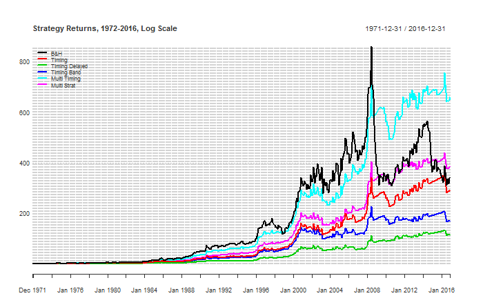

```r
Returns <- cbind.xts(AllAssets.xts$GSCI.ret,
                     AllAssets.xts$GSCI.10m.timingret,
                     AllAssets.xts$GSCI.10m.timingret.delayed,
                     AllAssets.xts$GSCI.10m.timingret.band,
                     AllAssets.xts$GSCI.avg.timingret,
                     AllAssets.xts$GSCI.avg.combo.band)[SubsetPeriod.Reporting]
colnames(Returns) <- Strategies
chart.CumReturns(Returns, wealth.index = TRUE,
  main = "Strategy Returns, 1972-2016, Log Scale",
  #colorset = c(4,2,3,5,6),
  legend.loc = "topleft",
  date.format = "%Y", ylab = "", ylog = TRUE)
```

[output not shown]

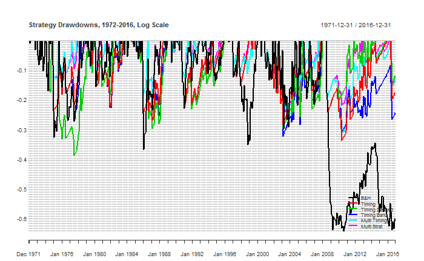

```r
chart.Drawdown(Returns,#[,-1], to exclude B&H
  main = "Strategy Drawdowns, 1972-2016, Log Scale",
  date.format = "%Y",
  #colorset = c(4,2,3,5,6),
  ylab = "Drawdown", legend.loc = "bottomright", major.ticks = "years",  minor.ticks = FALSE)
```

```r
TimeInMarket <- c(nrow(AllAssets.xts[SubsetPeriod.Reporting]),
                  sum(AllAssets.xts$GSCI.10m.signal[SubsetPeriod.Reporting]),
                  sum(AllAssets.xts$GSCI.10m.signal.delayed[SubsetPeriod.Reporting]),
                  sum(AllAssets.xts$GSCI.10m.signal.band[SubsetPeriod.Reporting]),
                  sum(AllAssets.xts$GSCI.avg.signal[SubsetPeriod.Reporting]),
                  sum(AllAssets.xts$GSCI.avg.combo.band.signal[SubsetPeriod.Reporting]))/nrow(AllAssets.xts[SubsetPeriod.Reporting])
FullStats <- rbind(Return.annualized(Returns,scale = 12)*FormatMultiplier,
                   StdDev.annualized(Returns,scale = 12)*FormatMultiplier,
                   skewness(Returns),
                   kurtosis(Returns),
                   100*c(Return.annualized(AllAssets.ret$SACPI[SubsetPeriod.Reporting],scale = 12)),
                   TimeInMarket*FormatMultiplier,
                   apply(Returns, 2, function(x) length(x[x>0]))/nrow(Returns)*FormatMultiplier,
                   apply(Returns, 2, function(x) max(x, na.rm = TRUE))*FormatMultiplier,
                   apply(Returns, 2, function(x) min(x, na.rm = TRUE))*FormatMultiplier,
                   maxDrawdown(Returns,scale = 12,invert = FALSE)*FormatMultiplier,
                   -maxDrawdown(Returns,scale = 12,invert = FALSE)/Return.annualized(Returns,scale = 12),
                   SharpeRatio.annualized(Returns,Rf = AllAssets.ret$TBILLS[SubsetPeriod.Reporting]),
                   SortinoRatio(Returns, scale = 12), #what MAR?
                   CalmarRatio(Returns, scale = 12),
                   UlcerIndex(Returns)*FormatMultiplier)
colnames(FullStats) <- Strategies
rownames(FullStats) <- PerformanceMeasures
round(FullStats,2)
```

|  | B&H | Timing | Timing Delayed | Timing Band | Multi Timing | Multi Strat |
| --- | --- | --- | --- | --- | --- | --- |
| CAGR | 13.85 | 13.42 | 11.16 | 12.11 | 15.49 | 14.14 |
| Volatility | 22.91 | 19.04 | 17.38 | 18.75 | 17.11 | 15.22 |
| Skew | 0.21 | 0.59 | 0.20 | 0.63 | 0.88 | 0.51 |
| Kurtosis | 1.48 | 4.13 | 3.58 | 4.52 | 5.03 | 4.31 |
| Inflation CAGR | 9.48 | 9.48 | 9.48 | 9.48 | 9.48 | 9.48 |
| % in the Market | 100.00 | 69.32 | 62.29 | 65.62 | 64.94 | 56.48 |
| % positive Months | 59.89 | 72.46 | 74.68 | 73.38 | 70.24 | 71.90 |
| Best Month | 30.09 | 30.09 | 25.90 | 30.09 | 30.09 | 22.72 |
| Worst Month | -19.15 | -19.15 | -19.15 | -19.15 | -17.57 | -17.57 |
| Max Drawdown | -64.08 | -33.50 | -38.71 | -32.06 | -30.96 | -24.64 |

[output cut: 5 more lines]

```r
write.table(round(FullStats,4), "clipboard", sep="\t", col.names=NA)
write.table(round(Returns,4), "clipboard", sep="\t", col.names=NA)
```

#### GTAA

[output not shown]

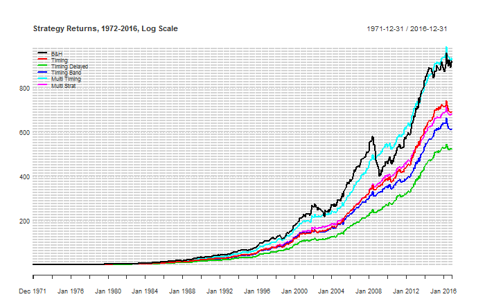

```r
Returns <- cbind.xts(AllAssets.xts$BuyandHold.ret,
                     AllAssets.xts$Timing.ret,
                     AllAssets.xts$DelayedTiming.ret,
                     AllAssets.xts$BandTiming.ret,
                     AllAssets.xts$Avg.Timing.ret,
                     AllAssets.xts$Avg.Combo.Band.ret)[SubsetPeriod.Reporting]
colnames(Returns) <- Strategies
chart.CumReturns(Returns, wealth.index = TRUE,
  main = "Strategy Returns, 1972-2016, Log Scale",
  #colorset = c(4,2,3,5,6),
  legend.loc = "topleft",
  date.format = "%Y", ylab = "", ylog = TRUE)
```

[output not shown]

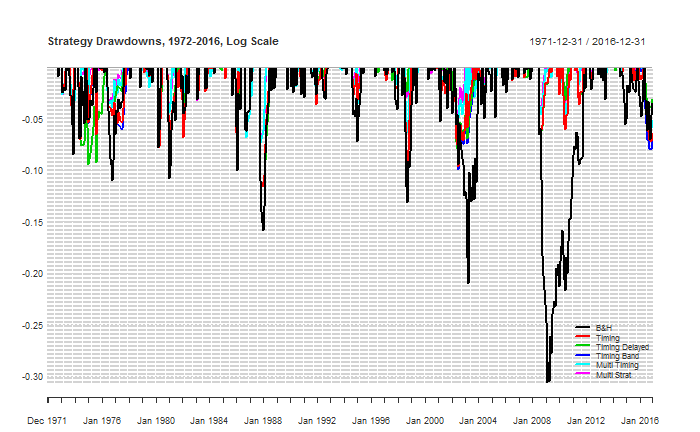

```r
chart.Drawdown(Returns,#[,-1], to exclude B&H
  main = "Strategy Drawdowns, 1972-2016, Log Scale",
  date.format = "%Y",
  #colorset = c(4,2,3,5,6),
  ylab = "Drawdown", legend.loc = "bottomright", major.ticks = "years",  minor.ticks = FALSE)
```

```r
TimeInMarket <- c(nrow(AllAssets.xts[SubsetPeriod.Reporting]),
                  sum(AllAssets.xts$Timing.signal[SubsetPeriod.Reporting]),
                  sum(AllAssets.xts$DelayedTiming.signal[SubsetPeriod.Reporting]),
                  sum(AllAssets.xts$BandTiming.signal[SubsetPeriod.Reporting]),
                  sum(AllAssets.xts$Avg.Timing.signal[SubsetPeriod.Reporting]),
                  sum(AllAssets.xts$Avg.Combo.Band.signal[SubsetPeriod.Reporting]))/nrow(AllAssets.xts[SubsetPeriod.Reporting])
FullStats <- rbind(Return.annualized(Returns,scale = 12)*FormatMultiplier,
                   StdDev.annualized(Returns,scale = 12)*FormatMultiplier,
                   skewness(Returns),
                   kurtosis(Returns),
                   100*c(Return.annualized(AllAssets.ret$SACPI[SubsetPeriod.Reporting],scale = 12)),
                   TimeInMarket*FormatMultiplier,
                   apply(Returns, 2, function(x) length(x[x>0]))/nrow(Returns)*FormatMultiplier,
                   apply(Returns, 2, function(x) max(x, na.rm = TRUE))*FormatMultiplier,
                   apply(Returns, 2, function(x) min(x, na.rm = TRUE))*FormatMultiplier,
                   maxDrawdown(Returns,scale = 12,invert = FALSE)*FormatMultiplier,
                   -maxDrawdown(Returns,scale = 12,invert = FALSE)/Return.annualized(Returns,scale = 12),
                   SharpeRatio.annualized(Returns,Rf = AllAssets.ret$TBILLS[SubsetPeriod.Reporting]),
                   SortinoRatio(Returns, scale = 12), #what MAR?
                   CalmarRatio(Returns, scale = 12),
                   UlcerIndex(Returns)*FormatMultiplier)
colnames(FullStats) <- Strategies
rownames(FullStats) <- PerformanceMeasures
round(FullStats,2)
```

|  | B&H | Timing | Timing Delayed | Timing Band | Multi Timing | Multi Strat |
| --- | --- | --- | --- | --- | --- | --- |
| CAGR | 16.36 | 15.63 | 14.92 | 15.32 | 16.39 | 15.59 |
| Volatility | 10.95 | 8.76 | 7.96 | 8.54 | 7.87 | 7.01 |
| Skew | 0.05 | 0.08 | -0.18 | 0.19 | 0.36 | 0.32 |
| Kurtosis | 1.74 | 3.96 | 2.52 | 4.14 | 3.36 | 3.31 |
| Inflation CAGR | 9.48 | 9.48 | 9.48 | 9.48 | 9.48 | 9.48 |
| % in the Market | 100.00 | 77.40 | 71.72 | 73.24 | 71.38 | 61.93 |
| % positive Months | 66.54 | 71.90 | 73.20 | 72.27 | 74.86 | 75.23 |
| Best Month | 16.34 | 16.34 | 10.33 | 16.34 | 15.11 | 12.71 |
| Worst Month | -10.98 | -10.98 | -10.98 | -10.98 | -7.29 | -7.15 |
| Max Drawdown | -30.61 | -11.59 | -11.59 | -11.59 | -7.29 | -7.15 |

[output cut: 5 more lines]

```r
write.table(round(FullStats,4), "clipboard", sep="\t", col.names=NA)
write.table(round(Returns,4), "clipboard", sep="\t", col.names=NA)
```

Stats Including Property

```r
#remove past data
rm(list = ls(envir = globalenv()),envir = globalenv()) #clear Vars from global enviroment
#Load required packages
library(PerformanceAnalytics)
library(quantstrat)
#Set Symbols
symbols <- c("TBILLS","JALSH","MSCIWORLD","SA10YR","GSCI","JASPY","SACPI")
#Import saved pricing data csv files as xts
getSymbols(symbols,
           src = "csv",
           dir="../Data/CSV files/SA Long Term/",
           col.names=c("Close"))
```

```
[1] "TBILLS"    "JALSH"     "MSCIWORLD" "SA10YR"    "GSCI"      "JASPY"     "SACPI"
```

```r
#Define subset dates for different period
SubsetPeriod.Reporting <- "1993-12-31::2016-12-31"
SubsetPeriod.Calculations <- "1992-12-31::2016-12-31"
```

#### Calculating asset class returns and charting

Once the data is loaded we can create one xts object for the prices and calculate each asset class’s returns. The asset class returns are then charted.

[output not shown]

[figure not shown]

```r
AllAssets <- cbind.xts(Cl(TBILLS),
                       Cl(JALSH),
                       Cl(MSCIWORLD),
                       Cl(SA10YR),
                       Cl(GSCI),
                       Cl(JASPY),
                       Cl(SACPI))
AllAssets <- AllAssets[SubsetPeriod.Calculations]
colnames(AllAssets) <- symbols
#calculate returns and cum returns
AllAssets.ret <- Return.calculate(AllAssets)[-1,]
AllAssets.cumret <- 100*cumprod(1+ ROC(AllAssets, type = "discrete")[-1,])
#how do i add a row at the top with value of 100 for each? rbind?
chart.TimeSeries(AllAssets.cumret[SubsetPeriod.Reporting],
 main = "SA Asset Class Returns, 1994-2016, Log Scale",
 ylab = "",
 #ylog = TRUE,
 #ylim = c(100,250000),
 #date.format = "%Y",
 major.ticks = "years",
 legend.loc = "topleft",
 colorset = c("orangered3","olivedrab","slateblue","blue","gold2","dodgerblue2","cornflowerblue")
 #minor.ticks =FALSE
 )
```

```r
write.table(round(AllAssets.cumret,4), "clipboard", sep="\t", col.names=NA)
```

#### Analysing asset class returns, max drawdowns and other performance statistics

```r
#Create xts for Returns
Returns <- AllAssets.ret[SubsetPeriod.Reporting]
#calculate statistics and store as "stats"
stats <- rbind(100*Return.annualized(Returns,scale = 12),
               100*StdDev.annualized(Returns,scale = 12),
               SharpeRatio.annualized(Returns,Rf = AllAssets.ret$TBILLS),
               100*maxDrawdown(Returns,scale = 12,invert = FALSE),
               100*c(Return.annualized(Returns$SACPI,scale = 12)))
#rename table rows/column names and format
colnames(stats) <- symbols
rownames(stats) <- c("Return","Volatility",
                     paste("Sharpe (",round(stats[1,"TBILLS"],2),"%)", sep = ""),
                     "MaxDD","Inflation CAGR")
stats <- round(stats[,-7],2)
#print
stats
```

```
               TBILLS  JALSH MSCIWORLD SA10YR   GSCI  JASPY
Return           9.84  14.59     13.54  11.74   6.85  19.40
Volatility       1.01  18.37     16.32   8.04  23.01  15.85
Sharpe (9.84%)  -0.14   0.23      0.20   0.19  -0.13   0.54
MaxDD            0.00 -40.44    -49.90 -18.63 -64.08 -31.87
Inflation CAGR   6.19   6.19      6.19   6.19   6.19   6.19
```

```r
#copies stats to clipboad for pasting into word/excel
write.table(stats, "clipboard", sep="\t", col.names=NA)
```

#### Managing Risk

Lets chart each asset with its 10 month simple moving average

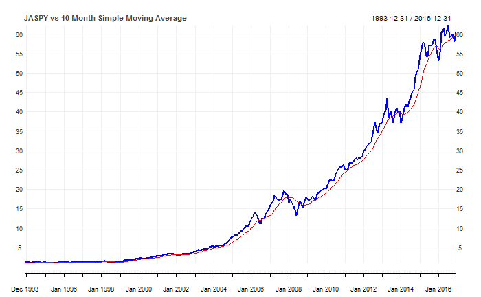

```r
myChart_Theme <- chart_theme() #Create a chart_theme
myChart_Theme$col$line.col <- "blue"
SMAperiod <- 10
chart_Series(Cl(JASPY),
  name = paste("JASPY vs 10 Month Simple Moving Average",sep = ""),
  theme=myChart_Theme,
  type = "line",
  subset = SubsetPeriod.Reporting,
  TA = 'add_SMA(n=SMAperiod, on=1, col="red")'
  )
```

```r
#change to other chart so can make it log?
```

#### Calculating returns

```r
#Import saved pricing data csv files as xts
getSymbols("TBILLYIELDS",
           src = "csv",
           dir="../Data/CSV files/SA Long Term/",
           col.names=c("Close"))
```

```
[1] "TBILLYIELDS"
```

```r
#load an additional library
library(dplyr)
#Create new all assets
AllAssets <- cbind.xts(Cl(JALSH),
                       Cl(MSCIWORLD),
                       Cl(SA10YR),
                       Cl(GSCI),
                       Cl(JASPY),
                       Cl(TBILLYIELDS))
AllAssets <- AllAssets[SubsetPeriod.Calculations]
#create dataframe - tidyverse not compatible with xts?
AllAssets.df <- data.frame(date=index(AllAssets), coredata(AllAssets)) #, row.names = index(AllAssets))
BuyBand <- 1.025
SellBand <- 1.00
#mutate new columns
AllAssets.df  <- mutate(AllAssets.df,
  "RF.ret" =  c(0,lag((TBILLYIELDS.Close/100)/12)[-1]),
  #is this right?
  "JALSH.ret" =  c(0,diff(JALSH.Close)/lag(JALSH.Close)[-1]),

  "JALSH.2m.SMA" =  rollmean(JALSH.Close,2,fill = 0,align = "right"),
  "JALSH.5m.SMA" =  rollmean(JALSH.Close,5,fill = 0,align = "right"),
  "JALSH.10m.SMA" =  rollmean(JALSH.Close,10,fill = 0,align = "right"),

  "JALSH.2m.signal" =  lag(ifelse(JALSH.Close>=JALSH.2m.SMA,1,0)),
  "JALSH.5m.signal" =  lag(ifelse(JALSH.Close>=JALSH.5m.SMA,1,0)),
  "JALSH.10m.signal" =  lag(ifelse(JALSH.Close>=JALSH.10m.SMA,1,0)),
  "JALSH.2m.signal.delayed" =  lag(ifelse(JALSH.Close>=JALSH.2m.SMA,ifelse(JALSH.2m.signal==1,1,0),0)),
  "JALSH.5m.signal.delayed" =  lag(ifelse(JALSH.Close>=JALSH.5m.SMA,ifelse(JALSH.5m.signal==1,1,0),0)),
  "JALSH.10m.signal.delayed" =  lag(ifelse(JALSH.Close>=JALSH.10m.SMA,ifelse(JALSH.10m.signal==1,1,0),0)),
  "JALSH.2m.timingret" = ifelse(JALSH.2m.signal == 1,JALSH.ret,RF.ret),
  "JALSH.5m.timingret" = ifelse(JALSH.5m.signal == 1,JALSH.ret,RF.ret),
  "JALSH.10m.timingret" = ifelse(JALSH.10m.signal == 1,JALSH.ret,RF.ret),
  "JALSH.2m.timingret.delayed" = ifelse(JALSH.2m.signal.delayed == 1,JALSH.ret,RF.ret),
  "JALSH.5m.timingret.delayed" = ifelse(JALSH.5m.signal.delayed == 1,JALSH.ret,RF.ret),
  "JALSH.10m.timingret.delayed" = ifelse(JALSH.10m.signal.delayed == 1,JALSH.ret,RF.ret),

  "JALSH.avg.timingret" = (JALSH.2m.timingret + JALSH.5m.timingret + JALSH.10m.timingret)/3,
  "JALSH.avg.signal" = (JALSH.2m.signal + JALSH.5m.signal + JALSH.10m.signal)/3,
  "JALSH.avg.timingret.delayed" = (JALSH.2m.timingret.delayed + JALSH.5m.timingret.delayed + JALSH.10m.timingret.delayed)/3,
  "JALSH.avg.signal.delayed" = (JALSH.2m.signal.delayed + JALSH.5m.signal.delayed + JALSH.10m.signal.delayed)/3,
  "JALSH.avg.combo" = (JALSH.avg.timingret + JALSH.avg.timingret.delayed)/2,
  "JALSH.avg.combo.signal" = (JALSH.avg.signal + JALSH.avg.signal.delayed)/2,
  "MSCIWORLD.ret" =  c(0,diff(MSCIWORLD.Close)/lag(MSCIWORLD.Close)[-1]),

  "MSCIWORLD.2m.SMA" =  rollmean(MSCIWORLD.Close,2,fill = 0,align = "right"),
  "MSCIWORLD.5m.SMA" =  rollmean(MSCIWORLD.Close,5,fill = 0,align = "right"),
  "MSCIWORLD.10m.SMA" =  rollmean(MSCIWORLD.Close,10,fill = 0,align = "right"),

  "MSCIWORLD.2m.signal" =  lag(ifelse(MSCIWORLD.Close>=MSCIWORLD.2m.SMA,1,0)),
  "MSCIWORLD.5m.signal" =  lag(ifelse(MSCIWORLD.Close>=MSCIWORLD.5m.SMA,1,0)),
  "MSCIWORLD.10m.signal" =  lag(ifelse(MSCIWORLD.Close>=MSCIWORLD.10m.SMA,1,0)),
  "MSCIWORLD.2m.signal.delayed" =  lag(ifelse(MSCIWORLD.Close>=MSCIWORLD.2m.SMA,ifelse(MSCIWORLD.2m.signal==1,1,0),0)),
  "MSCIWORLD.5m.signal.delayed" =  lag(ifelse(MSCIWORLD.Close>=MSCIWORLD.5m.SMA,ifelse(MSCIWORLD.5m.signal==1,1,0),0)),
  "MSCIWORLD.10m.signal.delayed" =  lag(ifelse(MSCIWORLD.Close>=MSCIWORLD.10m.SMA,ifelse(MSCIWORLD.10m.signal==1,1,0),0)),

  "MSCIWORLD.2m.timingret" = ifelse(MSCIWORLD.2m.signal == 1,MSCIWORLD.ret,RF.ret),
  "MSCIWORLD.5m.timingret" = ifelse(MSCIWORLD.5m.signal == 1,MSCIWORLD.ret,RF.ret),
  "MSCIWORLD.10m.timingret" = ifelse(MSCIWORLD.10m.signal == 1,MSCIWORLD.ret,RF.ret),
  "MSCIWORLD.2m.timingret.delayed" = ifelse(MSCIWORLD.2m.signal.delayed == 1,MSCIWORLD.ret,RF.ret),
  "MSCIWORLD.5m.timingret.delayed" = ifelse(MSCIWORLD.5m.signal.delayed == 1,MSCIWORLD.ret,RF.ret),
  "MSCIWORLD.10m.timingret.delayed" = ifelse(MSCIWORLD.10m.signal.delayed == 1,MSCIWORLD.ret,RF.ret),

  "MSCIWORLD.avg.timingret" = (MSCIWORLD.2m.timingret + MSCIWORLD.5m.timingret + MSCIWORLD.10m.timingret)/3,
  "MSCIWORLD.avg.signal" = (MSCIWORLD.2m.signal + MSCIWORLD.5m.signal + MSCIWORLD.10m.signal)/3,
  "MSCIWORLD.avg.timingret.delayed" = (MSCIWORLD.2m.timingret.delayed + MSCIWORLD.5m.timingret.delayed + MSCIWORLD.10m.timingret.delayed)/3,
  "MSCIWORLD.avg.signal.delayed" = (MSCIWORLD.2m.signal.delayed + MSCIWORLD.5m.signal.delayed + MSCIWORLD.10m.signal.delayed)/3,
  "MSCIWORLD.avg.combo" = (MSCIWORLD.avg.timingret + MSCIWORLD.avg.timingret.delayed)/2,
  "MSCIWORLD.avg.combo.signal" = (MSCIWORLD.avg.signal + MSCIWORLD.avg.signal.delayed)/2,

  "MSCIWORLD.avg.combo" = (MSCIWORLD.avg.timingret + MSCIWORLD.avg.timingret.delayed)/2,
  "MSCIWORLD.avg.combo.signal" = (MSCIWORLD.avg.signal + MSCIWORLD.avg.signal.delayed)/2,

  "SA10YR.ret" =  c(0,diff(SA10YR.Close)/lag(SA10YR.Close)[-1]),

  "SA10YR.2m.SMA" =  rollmean(SA10YR.Close,2,fill = 0,align = "right"),
  "SA10YR.5m.SMA" =  rollmean(SA10YR.Close,5,fill = 0,align = "right"),
  "SA10YR.10m.SMA" =  rollmean(SA10YR.Close,10,fill = 0,align = "right"),

  "SA10YR.2m.signal" =  lag(ifelse(SA10YR.Close>=SA10YR.2m.SMA,1,0)),
  "SA10YR.5m.signal" =  lag(ifelse(SA10YR.Close>=SA10YR.5m.SMA,1,0)),
  "SA10YR.10m.signal" =  lag(ifelse(SA10YR.Close>=SA10YR.10m.SMA,1,0)),
  "SA10YR.2m.signal.delayed" =  lag(ifelse(SA10YR.Close>=SA10YR.2m.SMA,ifelse(SA10YR.2m.signal==1,1,0),0)),
  "SA10YR.5m.signal.delayed" =  lag(ifelse(SA10YR.Close>=SA10YR.5m.SMA,ifelse(SA10YR.5m.signal==1,1,0),0)),
  "SA10YR.10m.signal.delayed" =  lag(ifelse(SA10YR.Close>=SA10YR.10m.SMA,ifelse(SA10YR.10m.signal==1,1,0),0)),

  "SA10YR.2m.timingret" = ifelse(SA10YR.2m.signal == 1,SA10YR.ret,RF.ret),
  "SA10YR.5m.timingret" = ifelse(SA10YR.5m.signal == 1,SA10YR.ret,RF.ret),
  "SA10YR.10m.timingret" = ifelse(SA10YR.10m.signal == 1,SA10YR.ret,RF.ret),
  "SA10YR.2m.timingret.delayed" = ifelse(SA10YR.2m.signal.delayed == 1,SA10YR.ret,RF.ret),
  "SA10YR.5m.timingret.delayed" = ifelse(SA10YR.5m.signal.delayed == 1,SA10YR.ret,RF.ret),
  "SA10YR.10m.timingret.delayed" = ifelse(SA10YR.10m.signal.delayed == 1,SA10YR.ret,RF.ret),
```

```r
  "SA10YR.avg.timingret" = (SA10YR.2m.timingret + SA10YR.5m.timingret + SA10YR.10m.timingret)/3,
  "SA10YR.avg.signal" = (SA10YR.2m.signal + SA10YR.5m.signal + SA10YR.10m.signal)/3,
  "SA10YR.avg.timingret.delayed" = (SA10YR.2m.timingret.delayed + SA10YR.5m.timingret.delayed + SA10YR.10m.timingret.delayed)/3,
  "SA10YR.avg.signal.delayed" = (SA10YR.2m.signal.delayed + SA10YR.5m.signal.delayed + SA10YR.10m.signal.delayed)/3,
  "SA10YR.avg.combo" = (SA10YR.avg.timingret + SA10YR.avg.timingret.delayed)/2,
  "SA10YR.avg.combo.signal" = (SA10YR.avg.signal + SA10YR.avg.signal.delayed)/2,
  "GSCI.ret" =  c(0,diff(GSCI.Close)/lag(GSCI.Close)[-1]),

  "GSCI.2m.SMA" =  rollmean(GSCI.Close,2,fill = 0,align = "right"),
  "GSCI.5m.SMA" =  rollmean(GSCI.Close,5,fill = 0,align = "right"),
  "GSCI.10m.SMA" =  rollmean(GSCI.Close,10,fill = 0,align = "right"),

  "GSCI.2m.signal" =  lag(ifelse(GSCI.Close>=GSCI.2m.SMA,1,0)),
  "GSCI.5m.signal" =  lag(ifelse(GSCI.Close>=GSCI.5m.SMA,1,0)),
  "GSCI.10m.signal" =  lag(ifelse(GSCI.Close>=GSCI.10m.SMA,1,0)),
  "GSCI.2m.signal.delayed" =  lag(ifelse(GSCI.Close>=GSCI.2m.SMA,ifelse(GSCI.2m.signal==1,1,0),0)),
  "GSCI.5m.signal.delayed" =  lag(ifelse(GSCI.Close>=GSCI.5m.SMA,ifelse(GSCI.5m.signal==1,1,0),0)),
  "GSCI.10m.signal.delayed" =  lag(ifelse(GSCI.Close>=GSCI.10m.SMA,ifelse(GSCI.10m.signal==1,1,0),0)),

  "GSCI.2m.timingret" = ifelse(GSCI.2m.signal == 1,GSCI.ret,RF.ret),
  "GSCI.5m.timingret" = ifelse(GSCI.5m.signal == 1,GSCI.ret,RF.ret),
  "GSCI.10m.timingret" = ifelse(GSCI.10m.signal == 1,GSCI.ret,RF.ret),
  "GSCI.2m.timingret.delayed" = ifelse(GSCI.2m.signal.delayed == 1,GSCI.ret,RF.ret),
  "GSCI.5m.timingret.delayed" = ifelse(GSCI.5m.signal.delayed == 1,GSCI.ret,RF.ret),
  "GSCI.10m.timingret.delayed" = ifelse(GSCI.10m.signal.delayed == 1,GSCI.ret,RF.ret),
  "GSCI.avg.timingret" = (GSCI.2m.timingret + GSCI.5m.timingret + GSCI.10m.timingret)/3,
  "GSCI.avg.signal" = (GSCI.2m.signal + GSCI.5m.signal + GSCI.10m.signal)/3,
  "GSCI.avg.timingret.delayed" = (GSCI.2m.timingret.delayed + GSCI.5m.timingret.delayed + GSCI.10m.timingret.delayed)/3,
  "GSCI.avg.signal.delayed" = (GSCI.2m.signal.delayed + GSCI.5m.signal.delayed + GSCI.10m.signal.delayed)/3,
  "GSCI.avg.combo" = (GSCI.avg.timingret + GSCI.avg.timingret.delayed)/2,
  "GSCI.avg.combo.signal" = (GSCI.avg.signal + GSCI.avg.signal.delayed)/2,
  "JASPY.ret" =  c(0,diff(JASPY.Close)/lag(JASPY.Close)[-1]),

  "JASPY.2m.SMA" =  rollmean(JASPY.Close,2,fill = 0,align = "right"),
  "JASPY.5m.SMA" =  rollmean(JASPY.Close,5,fill = 0,align = "right"),
  "JASPY.10m.SMA" =  rollmean(JASPY.Close,10,fill = 0,align = "right"),

  "JASPY.2m.signal" =  lag(ifelse(JASPY.Close>=JASPY.2m.SMA,1,0)),
  "JASPY.5m.signal" =  lag(ifelse(JASPY.Close>=JASPY.5m.SMA,1,0)),
  "JASPY.10m.signal" =  lag(ifelse(JASPY.Close>=JASPY.10m.SMA,1,0)),
  "JASPY.2m.signal.delayed" =  lag(ifelse(JASPY.Close>=JASPY.2m.SMA,ifelse(JASPY.2m.signal==1,1,0),0)),
  "JASPY.5m.signal.delayed" =  lag(ifelse(JASPY.Close>=JASPY.5m.SMA,ifelse(JASPY.5m.signal==1,1,0),0)),
  "JASPY.10m.signal.delayed" =  lag(ifelse(JASPY.Close>=JASPY.10m.SMA,ifelse(JASPY.10m.signal==1,1,0),0)),

  "JASPY.2m.timingret" = ifelse(JASPY.2m.signal == 1,JASPY.ret,RF.ret),
  "JASPY.5m.timingret" = ifelse(JASPY.5m.signal == 1,JASPY.ret,RF.ret),
  "JASPY.10m.timingret" = ifelse(JASPY.10m.signal == 1,JASPY.ret,RF.ret),
  "JASPY.2m.timingret.delayed" = ifelse(JASPY.2m.signal.delayed == 1,JASPY.ret,RF.ret),
  "JASPY.5m.timingret.delayed" = ifelse(JASPY.5m.signal.delayed == 1,JASPY.ret,RF.ret),
  "JASPY.10m.timingret.delayed" = ifelse(JASPY.10m.signal.delayed == 1,JASPY.ret,RF.ret),
  "JASPY.avg.timingret" = (JASPY.2m.timingret + JASPY.5m.timingret + JASPY.10m.timingret)/3,
  "JASPY.avg.signal" = (JASPY.2m.signal + JASPY.5m.signal + JASPY.10m.signal)/3,
  "JASPY.avg.timingret.delayed" = (JASPY.2m.timingret.delayed + JASPY.5m.timingret.delayed + JASPY.10m.timingret.delayed)/3,
  "JASPY.avg.signal.delayed" = (JASPY.2m.signal.delayed + JASPY.5m.signal.delayed + JASPY.10m.signal.delayed)/3,
  "JASPY.avg.combo" = (JASPY.avg.timingret + JASPY.avg.timingret.delayed)/2,
  "JASPY.avg.combo.signal" = (JASPY.avg.signal + JASPY.avg.signal.delayed)/2,
  "JALSH.2m.signal.band" =  ifelse(row_number()<=2,0,
                                    lag(ifelse(JALSH.Close>=(BuyBand*JALSH.2m.SMA),1,
                                        ifelse(JALSH.Close<(SellBand*JALSH.2m.SMA),0,2)))),
  "JALSH.5m.signal.band" =  ifelse(row_number()<=5,0,
                                    lag(ifelse(JALSH.Close>=(BuyBand*JALSH.5m.SMA),1,
                                        ifelse(JALSH.Close<(SellBand*JALSH.5m.SMA),0,2)))),
  "JALSH.10m.signal.band" =  ifelse(row_number()<=10,0,
                                    lag(ifelse(JALSH.Close>=(BuyBand*JALSH.10m.SMA),1,
                                        ifelse(JALSH.Close<(SellBand*JALSH.10m.SMA),0,2)))),

  "MSCIWORLD.2m.signal.band" =  ifelse(row_number()<=2,0,
                                    lag(ifelse(MSCIWORLD.Close>=(BuyBand*MSCIWORLD.2m.SMA),1,
                                        ifelse(MSCIWORLD.Close<(SellBand*MSCIWORLD.2m.SMA),0,2)))),
  "MSCIWORLD.5m.signal.band" =  ifelse(row_number()<=5,0,
                                    lag(ifelse(MSCIWORLD.Close>=(BuyBand*MSCIWORLD.5m.SMA),1,
                                        ifelse(MSCIWORLD.Close<(SellBand*MSCIWORLD.5m.SMA),0,2)))),
  "MSCIWORLD.10m.signal.band" =  ifelse(row_number()<=10,0,
                                    lag(ifelse(MSCIWORLD.Close>=(BuyBand*MSCIWORLD.10m.SMA),1,
                                        ifelse(MSCIWORLD.Close<(SellBand*MSCIWORLD.10m.SMA),0,2)))),

  "SA10YR.2m.signal.band" =  ifelse(row_number()<=2,0,
                                    lag(ifelse(SA10YR.Close>=(BuyBand*SA10YR.2m.SMA),1,
                                        ifelse(SA10YR.Close<(SellBand*SA10YR.2m.SMA),0,2)))),
  "SA10YR.5m.signal.band" =  ifelse(row_number()<=5,0,
                                    lag(ifelse(SA10YR.Close>=(BuyBand*SA10YR.5m.SMA),1,
                                        ifelse(SA10YR.Close<(SellBand*SA10YR.5m.SMA),0,2)))),
  "SA10YR.10m.signal.band" =  ifelse(row_number()<=10,0,
                                    lag(ifelse(SA10YR.Close>=(BuyBand*SA10YR.10m.SMA),1,
                                        ifelse(SA10YR.Close<(SellBand*SA10YR.10m.SMA),0,2)))),
  "GSCI.2m.signal.band" =  ifelse(row_number()<=2,0,
                                    lag(ifelse(GSCI.Close>=(BuyBand*GSCI.2m.SMA),1,
                                        ifelse(GSCI.Close<(SellBand*GSCI.2m.SMA),0,2)))),
  "GSCI.5m.signal.band" =  ifelse(row_number()<=5,0,
                                    lag(ifelse(GSCI.Close>=(BuyBand*GSCI.5m.SMA),1,
                                        ifelse(GSCI.Close<(SellBand*GSCI.5m.SMA),0,2)))),
  "GSCI.10m.signal.band" =  ifelse(row_number()<=10,0,
                                    lag(ifelse(GSCI.Close>=(BuyBand*GSCI.10m.SMA),1,
                                        ifelse(GSCI.Close<(SellBand*GSCI.10m.SMA),0,2)))),
```

```r
  "JASPY.2m.signal.band" =  ifelse(row_number()<=2,0,
                                    lag(ifelse(JASPY.Close>=(BuyBand*JASPY.2m.SMA),1,
                                        ifelse(JASPY.Close<(SellBand*JASPY.2m.SMA),0,2)))),
  "JASPY.5m.signal.band" =  ifelse(row_number()<=5,0,
                                    lag(ifelse(JASPY.Close>=(BuyBand*JASPY.5m.SMA),1,
                                        ifelse(JASPY.Close<(SellBand*JASPY.5m.SMA),0,2)))),
  "JASPY.10m.signal.band" =  ifelse(row_number()<=10,0,
                                    lag(ifelse(JASPY.Close>=(BuyBand*JASPY.10m.SMA),1,
                                        ifelse(JASPY.Close<(SellBand*JASPY.10m.SMA),0,2)))),

  "BuyandHold.ret" = (JALSH.ret + MSCIWORLD.ret + SA10YR.ret + GSCI.ret + JASPY.ret)/5,

  "Timing.ret" = (JALSH.10m.timingret + MSCIWORLD.10m.timingret
                  + SA10YR.10m.timingret + GSCI.10m.timingret + JASPY.10m.timingret)/5,
  "Timing.signal" = (JALSH.10m.signal + MSCIWORLD.10m.signal
                     + SA10YR.10m.signal + GSCI.10m.signal + JASPY.10m.signal)/5,

  "DelayedTiming.ret" = (JALSH.10m.timingret.delayed + MSCIWORLD.10m.timingret.delayed
                         + SA10YR.10m.timingret.delayed + GSCI.10m.timingret.delayed + JASPY.10m.timingret.delayed)/5,
  "DelayedTiming.signal" = (JALSH.10m.signal.delayed + MSCIWORLD.10m.signal.delayed
                            + SA10YR.10m.signal.delayed + GSCI.10m.signal.delayed + JASPY.10m.signal.delayed)/5,

  "Avg.Timing.ret" = (JALSH.avg.timingret + MSCIWORLD.avg.timingret
                      + SA10YR.avg.timingret + GSCI.avg.timingret+ JASPY.avg.timingret)/5,
  "Avg.Timing.signal" = (JALSH.avg.signal + MSCIWORLD.avg.signal
                         + SA10YR.avg.signal + GSCI.avg.signal + JASPY.avg.signal)/5,

  "Avg.DelayedTiming.ret" = (JALSH.avg.timingret.delayed + MSCIWORLD.avg.timingret.delayed +
                            SA10YR.avg.timingret.delayed + GSCI.avg.timingret.delayed + JASPY.avg.timingret.delayed)/5,
  "Avg.DelayedTiming.signal" = (JALSH.avg.signal.delayed + MSCIWORLD.avg.signal.delayed +
                            SA10YR.avg.signal.delayed + GSCI.avg.signal.delayed + JASPY.avg.signal.delayed)/5,

  "Avg.Combo.ret" = (JALSH.avg.combo + MSCIWORLD.avg.combo +
                            SA10YR.avg.combo + GSCI.avg.combo + JASPY.avg.combo)/5,
  "Avg.Combo.signal" = (JALSH.avg.combo.signal + MSCIWORLD.avg.combo.signal +
                            SA10YR.avg.combo.signal + GSCI.avg.combo.signal + JASPY.avg.combo.signal)/5

  )
# update signal for band strategy
for(i in 1:length(AllAssets.df$JALSH.10m.signal.band)){
  if(AllAssets.df$JALSH.2m.signal.band[i] == 2){AllAssets.df$JALSH.2m.signal.band[i] = AllAssets.df$JALSH.2m.signal.band[i-1]}
  if(AllAssets.df$JALSH.5m.signal.band[i] == 2){AllAssets.df$JALSH.5m.signal.band[i] = AllAssets.df$JALSH.5m.signal.band[i-1]}
  if(AllAssets.df$JALSH.10m.signal.band[i] == 2){AllAssets.df$JALSH.10m.signal.band[i] = AllAssets.df$JALSH.10m.signal.band[i-1]}

  if(AllAssets.df$MSCIWORLD.2m.signal.band[i] == 2){AllAssets.df$MSCIWORLD.2m.signal.band[i] = AllAssets.df$MSCIWORLD.2m.signal.band[i-1]}
  if(AllAssets.df$MSCIWORLD.5m.signal.band[i] == 2){AllAssets.df$MSCIWORLD.5m.signal.band[i] = AllAssets.df$MSCIWORLD.5m.signal.band[i-1]}
  if(AllAssets.df$MSCIWORLD.10m.signal.band[i] == 2){AllAssets.df$MSCIWORLD.10m.signal.band[i] = AllAssets.df$MSCIWORLD.10m.signal.band[i-1]}

  if(AllAssets.df$SA10YR.2m.signal.band[i] == 2){AllAssets.df$SA10YR.2m.signal.band[i] = AllAssets.df$SA10YR.2m.signal.band[i-1]}
  if(AllAssets.df$SA10YR.5m.signal.band[i] == 2){AllAssets.df$SA10YR.5m.signal.band[i] = AllAssets.df$SA10YR.5m.signal.band[i-1]}
  if(AllAssets.df$SA10YR.10m.signal.band[i] == 2){AllAssets.df$SA10YR.10m.signal.band[i] = AllAssets.df$SA10YR.10m.signal.band[i-1]}

  if(AllAssets.df$GSCI.2m.signal.band[i] == 2){AllAssets.df$GSCI.2m.signal.band[i] = AllAssets.df$GSCI.2m.signal.band[i-1]}
  if(AllAssets.df$GSCI.5m.signal.band[i] == 2){AllAssets.df$GSCI.5m.signal.band[i] = AllAssets.df$GSCI.5m.signal.band[i-1]}
  if(AllAssets.df$GSCI.10m.signal.band[i] == 2){AllAssets.df$GSCI.10m.signal.band[i] = AllAssets.df$GSCI.10m.signal.band[i-1]}

  if(AllAssets.df$JASPY.2m.signal.band[i] == 2){AllAssets.df$JASPY.2m.signal.band[i] = AllAssets.df$JASPY.2m.signal.band[i-1]}
  if(AllAssets.df$JASPY.5m.signal.band[i] == 2){AllAssets.df$JASPY.5m.signal.band[i] = AllAssets.df$JASPY.5m.signal.band[i-1]}
  if(AllAssets.df$JASPY.10m.signal.band[i] == 2){AllAssets.df$JASPY.10m.signal.band[i] = AllAssets.df$JASPY.10m.signal.band[i-1]}
}
#calculat returns for band strategy
AllAssets.df  <- mutate(AllAssets.df,
  "JALSH.2m.timingret.band" = ifelse(JALSH.2m.signal.band == 1,JALSH.ret,RF.ret),
  "JALSH.5m.timingret.band" = ifelse(JALSH.5m.signal.band == 1,JALSH.ret,RF.ret),
  "JALSH.10m.timingret.band" = ifelse(JALSH.10m.signal.band == 1,JALSH.ret,RF.ret),

  "JALSH.avg.timingret.band" = (JALSH.2m.timingret.band + JALSH.5m.timingret.band + JALSH.10m.timingret.band)/3,
  "JALSH.avg.signal.band" = (JALSH.2m.signal.band + JALSH.5m.signal.band + JALSH.10m.signal.band)/3,
  "JALSH.avg.combo.band" = (JALSH.avg.timingret + JALSH.avg.timingret.delayed  + JALSH.avg.timingret.band)/3,
  "JALSH.avg.combo.band.signal" = (JALSH.avg.signal + JALSH.avg.signal.delayed + JALSH.avg.signal.band)/3,
  "MSCIWORLD.2m.timingret.band" = ifelse(MSCIWORLD.2m.signal.band == 1,MSCIWORLD.ret,RF.ret),
  "MSCIWORLD.5m.timingret.band" = ifelse(MSCIWORLD.5m.signal.band == 1,MSCIWORLD.ret,RF.ret),
  "MSCIWORLD.10m.timingret.band" = ifelse(MSCIWORLD.10m.signal.band == 1,MSCIWORLD.ret,RF.ret),

  "MSCIWORLD.avg.timingret.band" = (MSCIWORLD.2m.timingret.band + MSCIWORLD.5m.timingret.band + MSCIWORLD.10m.timingret.band)/3,
  "MSCIWORLD.avg.signal.band" = (MSCIWORLD.2m.signal.band + MSCIWORLD.5m.signal.band + MSCIWORLD.10m.signal.band)/3,
  "MSCIWORLD.avg.combo.band" = (MSCIWORLD.avg.timingret + MSCIWORLD.avg.timingret.delayed  + MSCIWORLD.avg.timingret.band)/3,
  "MSCIWORLD.avg.combo.band.signal" = (MSCIWORLD.avg.signal + MSCIWORLD.avg.signal.delayed + MSCIWORLD.avg.signal.band)/3,
```

```r
  "SA10YR.2m.timingret.band" = ifelse(SA10YR.2m.signal.band == 1,SA10YR.ret,RF.ret),
  "SA10YR.5m.timingret.band" = ifelse(SA10YR.5m.signal.band == 1,SA10YR.ret,RF.ret),
  "SA10YR.10m.timingret.band" = ifelse(SA10YR.10m.signal.band == 1,SA10YR.ret,RF.ret),

  "SA10YR.avg.timingret.band" = (SA10YR.2m.timingret.band + SA10YR.5m.timingret.band + SA10YR.10m.timingret.band)/3,
  "SA10YR.avg.signal.band" = (SA10YR.2m.signal.band + SA10YR.5m.signal.band + SA10YR.10m.signal.band)/3,
  "SA10YR.avg.combo.band" = (SA10YR.avg.timingret + SA10YR.avg.timingret.delayed  + SA10YR.avg.timingret.band)/3,
  "SA10YR.avg.combo.band.signal" = (SA10YR.avg.signal + SA10YR.avg.signal.delayed + SA10YR.avg.signal.band)/3,

  "GSCI.2m.timingret.band" = ifelse(GSCI.2m.signal.band == 1,GSCI.ret,RF.ret),
  "GSCI.5m.timingret.band" = ifelse(GSCI.5m.signal.band == 1,GSCI.ret,RF.ret),
  "GSCI.10m.timingret.band" = ifelse(GSCI.10m.signal.band == 1,GSCI.ret,RF.ret),

  "GSCI.avg.timingret.band" = (GSCI.2m.timingret.band + GSCI.5m.timingret.band + GSCI.10m.timingret.band)/3,
  "GSCI.avg.signal.band" = (GSCI.2m.signal.band + GSCI.5m.signal.band + GSCI.10m.signal.band)/3,
  "GSCI.avg.combo.band" = (GSCI.avg.timingret + GSCI.avg.timingret.delayed  + GSCI.avg.timingret.band)/3,
  "GSCI.avg.combo.band.signal" = (GSCI.avg.signal + GSCI.avg.signal.delayed + GSCI.avg.signal.band)/3,

  "JASPY.2m.timingret.band" = ifelse(JASPY.2m.signal.band == 1,JASPY.ret,RF.ret),
  "JASPY.5m.timingret.band" = ifelse(JASPY.5m.signal.band == 1,JASPY.ret,RF.ret),
  "JASPY.10m.timingret.band" = ifelse(JASPY.10m.signal.band == 1,JASPY.ret,RF.ret),

  "JASPY.avg.timingret.band" = (JASPY.2m.timingret.band + JASPY.5m.timingret.band + JASPY.10m.timingret.band)/3,
  "JASPY.avg.signal.band" = (JASPY.2m.signal.band + JASPY.5m.signal.band + JASPY.10m.signal.band)/3,
  "JASPY.avg.combo.band" = (JASPY.avg.timingret + JASPY.avg.timingret.delayed  + JASPY.avg.timingret.band)/3,
  "JASPY.avg.combo.band.signal" = (JASPY.avg.signal + JASPY.avg.signal.delayed + JASPY.avg.signal.band)/3,
  "BandTiming.ret" = (JALSH.10m.timingret.band + MSCIWORLD.10m.timingret.band
                         + SA10YR.10m.timingret.band + GSCI.10m.timingret.band + JASPY.10m.timingret.band)/5,
  "BandTiming.signal" = (JALSH.10m.signal.band + MSCIWORLD.10m.signal.band
                            + SA10YR.10m.signal.band + GSCI.10m.signal.band + JASPY.10m.signal.band)/5,
  "Avg.BandTiming.ret" = (JALSH.avg.timingret.band + MSCIWORLD.avg.timingret.band +
                            SA10YR.avg.timingret.band + GSCI.avg.timingret.band + JASPY.avg.timingret.band)/5,
  "Avg.BandTiming.signal" = (JALSH.avg.signal.band + MSCIWORLD.avg.signal.band +
                            SA10YR.avg.signal.band + GSCI.avg.signal.band + JASPY.avg.signal.band)/5,
  "Avg.Combo.Band.ret" = (JALSH.avg.combo.band + MSCIWORLD.avg.combo.band +
                            SA10YR.avg.combo.band + GSCI.avg.combo.band + JASPY.avg.combo.band)/5,
  "Avg.Combo.Band.signal" = (JALSH.avg.combo.band.signal + MSCIWORLD.avg.combo.band.signal +
                            SA10YR.avg.combo.band.signal + GSCI.avg.combo.band.signal + JASPY.avg.combo.band.signal)/5,
  #put in WMAF / SAMAF
  "WMAF.BuyandHold.ret" = (JALSH.ret * 0.225
                           +MSCIWORLD.ret * 0.225
                           +SA10YR.ret * 0.225
                           +GSCI.ret * 0.1
                           +JASPY.ret * 0.225),

  "WMAF.Timing.ret" = (JALSH.10m.timingret * 0.225
                       +MSCIWORLD.10m.timingret * 0.225
                       +SA10YR.10m.timingret * 0.225
                       +GSCI.10m.timingret * 0.1
                       +JASPY.10m.timingret * 0.225 ),

  "WMAF.Timing.signal" = (JALSH.10m.signal * 0.225
                          +MSCIWORLD.10m.signal * 0.225
                          +SA10YR.10m.signal * 0.225
                          +GSCI.10m.signal * 0.1
                          +JASPY.10m.signal * 0.225 ),

  "WMAF.Avg.Combo.Band.ret" = (JALSH.avg.combo.band * 0.225
                               +MSCIWORLD.avg.combo.band * 0.225
                               +SA10YR.avg.combo.band * 0.225
                               +GSCI.avg.combo.band * 0.1
                               +JASPY.avg.combo.band * 0.225 ),

  "WMAF.Avg.Combo.Band.signal" = (JALSH.avg.combo.band.signal * 0.225
                                  +MSCIWORLD.avg.combo.band.signal * 0.225
                                  +SA10YR.avg.combo.band.signal * 0.225
                                  +GSCI.avg.combo.band.signal * 0.1
                                  +JASPY.avg.combo.band.signal * 0.225 ),

  "SAMAF.BuyandHold.ret" = (JALSH.ret * 0.20
                           +MSCIWORLD.ret * 0.20
                           +SA10YR.ret * 0.25
                           +GSCI.ret * 0.1
                           +JASPY.ret * 0.25),

  "SAMAF.Timing.ret" = (JALSH.10m.timingret * 0.20
                       +MSCIWORLD.10m.timingret * 0.20
                       +SA10YR.10m.timingret * 0.25
                       +GSCI.10m.timingret * 0.1
                       +JASPY.10m.timingret * 0.25 ),

  "SAMAF.Timing.signal" = (JALSH.10m.signal * 0.20
                          +MSCIWORLD.10m.signal * 0.20
                          +SA10YR.10m.signal * 0.25
                          +GSCI.10m.signal * 0.1
                          +JASPY.10m.signal * 0.25 ),

  "SAMAF.Avg.Combo.Band.ret" = (JALSH.avg.combo.band * 0.20
                               +MSCIWORLD.avg.combo.band * 0.20
                               +SA10YR.avg.combo.band * 0.25
                               +GSCI.avg.combo.band * 0.1
                               +JASPY.avg.combo.band * 0.25 ),

  "SAMAF.Avg.Combo.Band.signal" = (JALSH.avg.combo.band.signal * 0.20
                                  +MSCIWORLD.avg.combo.band.signal * 0.15
                                  +SA10YR.avg.combo.band.signal * 0.25
                                  +GSCI.avg.combo.band.signal * 0.1
                                  +JASPY.avg.combo.band.signal * 0.25 )
```

```r
  )
rownames(AllAssets.df) <- index(AllAssets)
#Create xts of calculations to analyse performance
AllAssets.xts <- xts(AllAssets.df[,-1], order.by = AllAssets.df$date)
#detach the packagae dplyr as it isn't compatible with other packages?
detach(package:dplyr)
```

#### Individual Asset Class Strategy Comparisons and Stats

```r
#for calculating the sharpe ratio later
Rf.ret <- Return.calculate(TBILLYIELDS)[-1,]
Rf.ret <- Rf.ret[SubsetPeriod.Reporting]
FormatMultiplier <- 100
Strategies <- c("B&H","Timing","Timing Delayed","Timing Band","Multi Timing","Multi Strat")
PerformanceMeasures <- c("CAGR","Volatility","Skew","Kurtosis","Inflation CAGR","% in the Market","% positive Months","Best Month","Worst Month","Max Drawdown","Max Drawdown / CAGR",paste("Sharpe Ratio (",round(100*Return.annualized(Return.calculate(TBILLS)[SubsetPeriod.Reporting]),2),"%)", sep = ""),"Sortino Ratio","MAR Ratio","Ulcer Index")
```

#### JASPY

[output not shown]

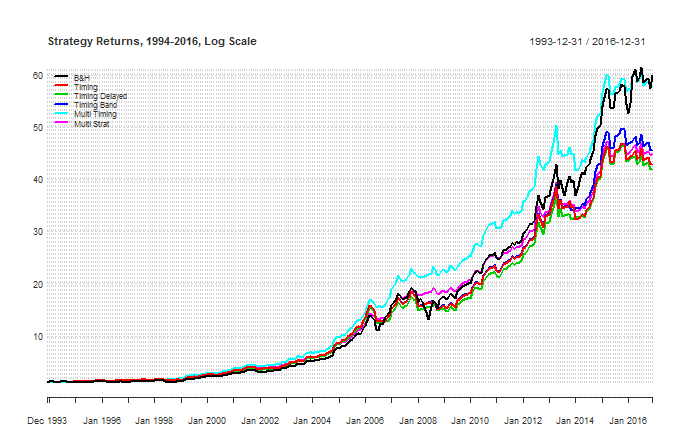

```r
Returns <- cbind.xts(AllAssets.xts$JASPY.ret,
                     AllAssets.xts$JASPY.10m.timingret,
                     AllAssets.xts$JASPY.10m.timingret.delayed,
                     AllAssets.xts$JASPY.10m.timingret.band,
                     AllAssets.xts$JASPY.avg.timingret,
                     AllAssets.xts$JASPY.avg.combo.band)[SubsetPeriod.Reporting]
colnames(Returns) <- Strategies
chart.CumReturns(Returns, wealth.index = TRUE,
  main = "Strategy Returns, 1994-2016, Log Scale",
  #colorset = c(4,2,3,5,6),
  legend.loc = "topleft",
  date.format = "%Y", ylab = "", ylog = TRUE)
```

[output not shown]

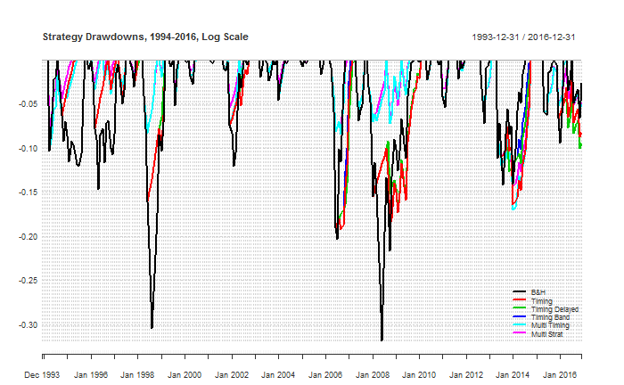

```r
chart.Drawdown(Returns,#[,-1], to exclude B&H
  main = "Strategy Drawdowns, 1994-2016, Log Scale",
  date.format = "%Y",
  #colorset = c(4,2,3,5,6),
  ylab = "Drawdown", legend.loc = "bottomright", major.ticks = "years",  minor.ticks = FALSE)
```

```r
TimeInMarket <- c(nrow(AllAssets.xts[SubsetPeriod.Reporting]),
                  sum(AllAssets.xts$JASPY.10m.signal[SubsetPeriod.Reporting]),
                  sum(AllAssets.xts$JASPY.10m.signal.delayed[SubsetPeriod.Reporting]),
                  sum(AllAssets.xts$JASPY.10m.signal.band[SubsetPeriod.Reporting]),
                  sum(AllAssets.xts$JASPY.avg.signal[SubsetPeriod.Reporting]),
                  sum(AllAssets.xts$JASPY.avg.combo.band.signal[SubsetPeriod.Reporting]))/nrow(AllAssets.xts[SubsetPeriod.Reporting])
FullStats <- rbind(Return.annualized(Returns,scale = 12)*FormatMultiplier,
                   StdDev.annualized(Returns,scale = 12)*FormatMultiplier,
                   skewness(Returns),
                   kurtosis(Returns),
                   100*c(Return.annualized(AllAssets.ret$SACPI[SubsetPeriod.Reporting],scale = 12)),
                   TimeInMarket*FormatMultiplier,
                   apply(Returns, 2, function(x) length(x[x>0]))/nrow(Returns)*FormatMultiplier,
                   apply(Returns, 2, function(x) max(x, na.rm = TRUE))*FormatMultiplier,
                   apply(Returns, 2, function(x) min(x, na.rm = TRUE))*FormatMultiplier,
                   maxDrawdown(Returns,scale = 12,invert = FALSE)*FormatMultiplier,
                   -maxDrawdown(Returns,scale = 12,invert = FALSE)/Return.annualized(Returns,scale = 12),
                   SharpeRatio.annualized(Returns,Rf = AllAssets.ret$TBILLS[SubsetPeriod.Reporting]),
                   SortinoRatio(Returns, scale = 12), #what MAR?
                   CalmarRatio(Returns, scale = 12),
                   UlcerIndex(Returns)*FormatMultiplier)
colnames(FullStats) <- Strategies
rownames(FullStats) <- PerformanceMeasures
round(FullStats,2)
```

|  | B&H | Timing | Timing Delayed | Timing Band | Multi Timing | Multi Strat |
| --- | --- | --- | --- | --- | --- | --- |
| CAGR | 19.40 | 17.71 | 17.60 | 18.02 | 19.24 | 17.93 |
| Volatility | 15.85 | 13.26 | 12.87 | 13.02 | 11.53 | 10.27 |
| Skew | -0.05 | -0.18 | -0.15 | -0.17 | 0.11 | 0.12 |
| Kurtosis | 1.15 | 2.35 | 2.86 | 2.62 | 2.01 | 2.14 |
| Inflation CAGR | 6.19 | 6.19 | 6.19 | 6.19 | 6.19 | 6.19 |
| % in the Market | 100.00 | 81.23 | 76.17 | 79.42 | 74.25 | 66.75 |
| % positive Months | 66.06 | 74.01 | 76.17 | 75.09 | 74.37 | 74.73 |
| Best Month | 18.19 | 14.52 | 14.52 | 14.52 | 13.45 | 13.42 |
| Worst Month | -13.93 | -13.93 | -13.93 | -13.93 | -11.09 | -11.09 |
| Max Drawdown | -31.87 | -19.25 | -19.00 | -19.00 | -17.02 | -14.34 |

[output cut: 5 more lines]

```r
write.table(round(FullStats,4), "clipboard", sep="\t", col.names=NA)
write.table(round(Returns,4), "clipboard", sep="\t", col.names=NA)
```

#### GTAA

[output not shown]

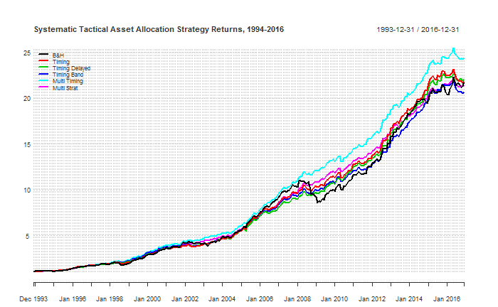

```r
Returns <- cbind.xts(AllAssets.xts$BuyandHold.ret,
                     AllAssets.xts$Timing.ret,
                     AllAssets.xts$DelayedTiming.ret,
                     AllAssets.xts$BandTiming.ret,
                     AllAssets.xts$Avg.Timing.ret,
                     AllAssets.xts$Avg.Combo.Band.ret)[SubsetPeriod.Reporting]
colnames(Returns) <- Strategies
chart.CumReturns(Returns, wealth.index = TRUE,
  main = "Systematic Tactical Asset Allocation Strategy Returns, 1994-2016",
  #colorset = c(4,2,3,5,6),
  legend.loc = "topleft",
  date.format = "%Y", ylab = "", ylog = TRUE)
```

[output not shown]

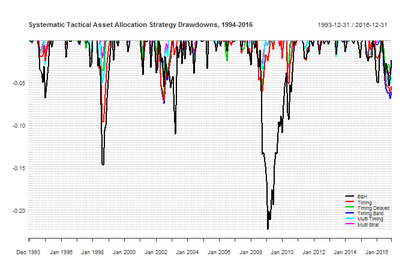

```r
chart.Drawdown(Returns,#[,-1], to exclude B&H
  main = "Systematic Tactical Asset Allocation Strategy Drawdowns, 1994-2016",
  date.format = "%Y",
  #colorset = c(4,2,3,5,6),
  ylab = "Drawdown", legend.loc = "bottomright", major.ticks = "years",  minor.ticks = FALSE)
```

```r
TimeInMarket <- c(nrow(AllAssets.xts[SubsetPeriod.Reporting]),
                  sum(AllAssets.xts$Timing.signal[SubsetPeriod.Reporting]),
                  sum(AllAssets.xts$DelayedTiming.signal[SubsetPeriod.Reporting]),
                  sum(AllAssets.xts$BandTiming.signal[SubsetPeriod.Reporting]),
                  sum(AllAssets.xts$Avg.Timing.signal[SubsetPeriod.Reporting]),
                  sum(AllAssets.xts$Avg.Combo.Band.signal[SubsetPeriod.Reporting]))/nrow(AllAssets.xts[SubsetPeriod.Reporting])
FullStats <- rbind(Return.annualized(Returns,scale = 12)*FormatMultiplier,
                   StdDev.annualized(Returns,scale = 12)*FormatMultiplier,
                   skewness(Returns),
                   kurtosis(Returns),
                   100*c(Return.annualized(AllAssets.ret$SACPI[SubsetPeriod.Reporting],scale = 12)),
                   TimeInMarket*FormatMultiplier,
                   apply(Returns, 2, function(x) length(x[x>0]))/nrow(Returns)*FormatMultiplier,
                   apply(Returns, 2, function(x) max(x, na.rm = TRUE))*FormatMultiplier,
                   apply(Returns, 2, function(x) min(x, na.rm = TRUE))*FormatMultiplier,
                   maxDrawdown(Returns,scale = 12,invert = FALSE)*FormatMultiplier,
                   -maxDrawdown(Returns,scale = 12,invert = FALSE)/Return.annualized(Returns,scale = 12),
                   SharpeRatio.annualized(Returns,Rf = AllAssets.ret$TBILLS[SubsetPeriod.Reporting]),
                   SortinoRatio(Returns, scale = 12), #what MAR?
                   CalmarRatio(Returns, scale = 12),
                   UlcerIndex(Returns)*FormatMultiplier)
colnames(FullStats) <- Strategies
rownames(FullStats) <- PerformanceMeasures
round(FullStats,2)
```

|  | B&H | Timing | Timing Delayed | Timing Band | Multi Timing | Multi Strat |
| --- | --- | --- | --- | --- | --- | --- |
| CAGR | 14.28 | 14.30 | 14.35 | 14.03 | 14.85 | 14.20 |
| Volatility | 9.44 | 7.04 | 6.47 | 6.70 | 6.29 | 5.44 |
| Skew | -0.11 | 0.03 | 0.42 | 0.21 | -0.03 | 0.11 |
| Kurtosis | 1.88 | 1.31 | 1.25 | 1.00 | 0.84 | 0.86 |
| Inflation CAGR | 6.19 | 6.19 | 6.19 | 6.19 | 6.19 | 6.19 |
| % in the Market | 100.00 | 76.17 | 70.54 | 72.42 | 70.11 | 60.87 |
| % positive Months | 65.34 | 71.48 | 74.01 | 72.56 | 75.09 | 76.17 |
| Best Month | 11.52 | 8.42 | 8.42 | 8.42 | 7.16 | 6.83 |
| Worst Month | -10.89 | -6.72 | -4.69 | -4.92 | -4.81 | -3.40 |
| Max Drawdown | -22.19 | -9.59 | -6.51 | -7.41 | -5.05 | -4.08 |

[output cut: 5 more lines]

```r
write.table(round(FullStats,4), "clipboard", sep="\t", col.names=NA)
write.table(round(Returns,4), "clipboard", sep="\t", col.names=NA)
```

#### GTAA for SAMAF

[output not shown]

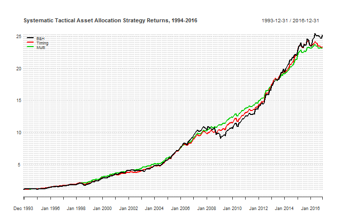

```r
Returns <- cbind.xts(AllAssets.xts$SAMAF.BuyandHold.ret,
                     AllAssets.xts$SAMAF.Timing.ret,
                     AllAssets.xts$SAMAF.Avg.Combo.Band.ret)[SubsetPeriod.Reporting]
colnames(Returns) <- c("B&H","Timing","Multi")
chart.CumReturns(Returns, wealth.index = TRUE,
  main = "Systematic Tactical Asset Allocation Strategy Returns, 1994-2016",
  #colorset = c(4,2,3,5,6),
  legend.loc = "topleft",
  date.format = "%Y", ylab = "", ylog = TRUE)
```

[output not shown]

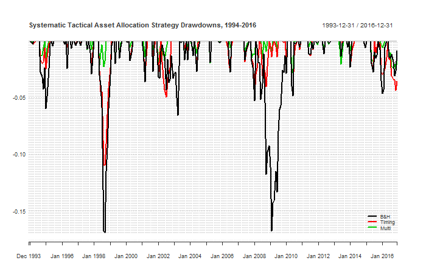

```r
chart.Drawdown(Returns,#[,-1], to exclude B&H
  main = "Systematic Tactical Asset Allocation Strategy Drawdowns, 1994-2016",
  date.format = "%Y",
  #colorset = c(4,2,3,5,6),
  ylab = "Drawdown", legend.loc = "bottomright", major.ticks = "years",  minor.ticks = FALSE)
```

```r
TimeInMarket <- c(nrow(AllAssets.xts[SubsetPeriod.Reporting]),
                  sum(AllAssets.xts$WMAF.Timing.signal[SubsetPeriod.Reporting]),
                  sum(AllAssets.xts$WMAF.Avg.Combo.Band.signal[SubsetPeriod.Reporting]),
                  nrow(AllAssets.xts[SubsetPeriod.Reporting]),
                  sum(AllAssets.xts$SAMAF.Timing.signal[SubsetPeriod.Reporting]),
                  sum(AllAssets.xts$SAMAF.Avg.Combo.Band.signal[SubsetPeriod.Reporting]))/nrow(AllAssets.xts[SubsetPeriod.Reporting])
FullStats <- rbind(Return.annualized(Returns,scale = 12)*FormatMultiplier,
                   StdDev.annualized(Returns,scale = 12)*FormatMultiplier,
                   skewness(Returns),
                   kurtosis(Returns),
                   100*c(Return.annualized(AllAssets.ret$SACPI[SubsetPeriod.Reporting],scale = 12)),
                   TimeInMarket*FormatMultiplier,
                   apply(Returns, 2, function(x) length(x[x>0]))/nrow(Returns)*FormatMultiplier,
                   apply(Returns, 2, function(x) max(x, na.rm = TRUE))*FormatMultiplier,
                   apply(Returns, 2, function(x) min(x, na.rm = TRUE))*FormatMultiplier,
                   maxDrawdown(Returns,scale = 12,invert = FALSE)*FormatMultiplier,
                   -maxDrawdown(Returns,scale = 12,invert = FALSE)/Return.annualized(Returns,scale = 12),
                   SharpeRatio.annualized(Returns,Rf = AllAssets.ret$TBILLS[SubsetPeriod.Reporting]),
                   SortinoRatio(Returns, scale = 12), #what MAR?
                   CalmarRatio(Returns, scale = 12),
                   UlcerIndex(Returns)*FormatMultiplier)
colnames(FullStats) <- colnames(Returns)
PerformanceMeasures <- c("CAGR","Volatility","Skew","Kurtosis","Inflation CAGR","% in the Market","% positive Months","Best Month","Worst Month","Max Drawdown","Max Drawdown / CAGR",paste("Sharpe Ratio (",round(100*Return.annualized(Return.calculate(TBILLS)[SubsetPeriod.Reporting]),2),"%)", sep = ""),"Sortino Ratio","MAR Ratio","Ulcer Index")
rownames(FullStats) <- PerformanceMeasures
round(FullStats,2)
```

|  | B&H | Timing | Multi |
| --- | --- | --- | --- |
| CAGR | 15.02 | 14.64 | 14.62 |
| Volatility | 8.90 | 6.81 | 5.18 |
| Skew | -0.23 | 0.16 | 0.34 |
| Kurtosis | 2.31 | 1.40 | 0.78 |
| Inflation CAGR | 6.19 | 6.19 | 6.19 |
| % in the Market | 100.00 | 78.38 | 62.38 |
| % positive Months | 68.95 | 71.84 | 79.78 |
| Best Month | 9.70 | 9.21 | 7.00 |
| Worst Month | -11.57 | -6.72 | -2.79 |
| Max Drawdown | -16.92 | -10.97 | -2.79 |

[output cut: 5 more lines]

```r
write.table(round(FullStats,4), "clipboard", sep="\t", col.names=NA)
```

#### GTAA for SAMAF with funds

```r
#Define subset dates for different period
SubsetPeriod.Reporting <- "2003-12-31::2016-12-31"
SubsetPeriod.Calculations <- "2002-01-31::2016-12-31"
getSymbols(c("ALSTABL","PRUINFA"),
           src = "csv",
           dir="../Data/CSV files/SA Long Term/",
           col.names=c("Close"))
```

```
[1] "ALSTABL" "PRUINFA"
```

```r
AllAssets2 <- cbind.xts(Cl(ALSTABL),
                       Cl(PRUINFA))
AllAssets2 <- AllAssets2[SubsetPeriod.Calculations]
colnames(AllAssets2) <- c("ALSTABL","PRUINFA")
#calculate returns and cum returns
AllAssets2.ret <- Return.calculate(AllAssets2)[-1,]
AllAssets2.cumret <- 100*cumprod(1+ ROC(AllAssets2, type = "discrete")[-1,])
```

[output not shown]

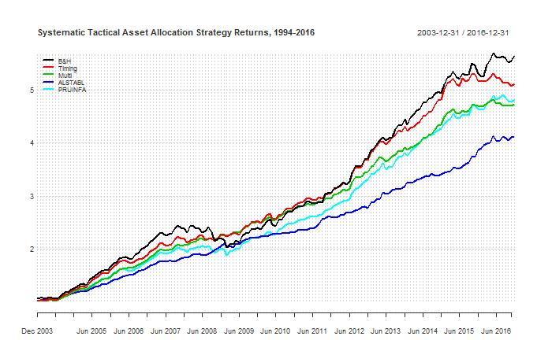

```r
Returns <- cbind.xts(AllAssets.xts$SAMAF.BuyandHold.ret,
                     AllAssets.xts$SAMAF.Timing.ret,
                     AllAssets.xts$SAMAF.Avg.Combo.Band.ret,
                     AllAssets2.ret$ALSTABL,
                     AllAssets2.ret$PRUINFA)[SubsetPeriod.Reporting]
colnames(Returns) <- c("B&H","Timing","Multi","ALSTABL","PRUINFA")
chart.CumReturns(Returns, wealth.index = TRUE,
  main = "Systematic Tactical Asset Allocation Strategy Returns, 1994-2016",
  #colorset = c(4,2,3,5,6),
  legend.loc = "topleft",
  date.format = "%Y", ylab = "", ylog = TRUE)
```

```r
chart.Drawdown(Returns,#[,-1], to exclude B&H
  main = "Systematic Tactical Asset Allocation Strategy Drawdowns, 1994-2016",
  date.format = "%Y",
  #colorset = c(4,2,3,5,6),
  ylab = "Drawdown", legend.loc = "bottomright", major.ticks = "years",  minor.ticks = FALSE)
```

[output not shown]

[output not shown]

```r
TimeInMarket <- c(nrow(AllAssets.xts[SubsetPeriod.Reporting]),
                  sum(AllAssets.xts$WMAF.Timing.signal[SubsetPeriod.Reporting]),
                  sum(AllAssets.xts$WMAF.Avg.Combo.Band.signal[SubsetPeriod.Reporting]),
                  nrow(AllAssets.xts[SubsetPeriod.Reporting]),
                  sum(AllAssets.xts$SAMAF.Timing.signal[SubsetPeriod.Reporting]),
                  sum(AllAssets.xts$SAMAF.Avg.Combo.Band.signal[SubsetPeriod.Reporting]))/nrow(AllAssets.xts[SubsetPeriod.Reporting])
FullStats <- rbind(Return.annualized(Returns,scale = 12)*FormatMultiplier,
                   StdDev.annualized(Returns,scale = 12)*FormatMultiplier,
                   skewness(Returns),
                   kurtosis(Returns),
                   100*c(Return.annualized(AllAssets.ret$SACPI[SubsetPeriod.Reporting],scale = 12)),
                   TimeInMarket*FormatMultiplier,
                   apply(Returns, 2, function(x) length(x[x>0]))/nrow(Returns)*FormatMultiplier,
                   apply(Returns, 2, function(x) max(x, na.rm = TRUE))*FormatMultiplier,
                   apply(Returns, 2, function(x) min(x, na.rm = TRUE))*FormatMultiplier,
                   maxDrawdown(Returns,scale = 12,invert = FALSE)*FormatMultiplier,
                   -maxDrawdown(Returns,scale = 12,invert = FALSE)/Return.annualized(Returns,scale = 12),
                   SharpeRatio.annualized(Returns,Rf = AllAssets.ret$TBILLS[SubsetPeriod.Reporting]),
                   SortinoRatio(Returns, scale = 12), #what MAR?
                   CalmarRatio(Returns, scale = 12),
                   UlcerIndex(Returns)*FormatMultiplier)
colnames(FullStats) <- colnames(Returns)
PerformanceMeasures <- c("CAGR","Volatility","Skew","Kurtosis","Inflation CAGR","% in the Market","% positive Months","Best Month","Worst Month","Max Drawdown","Max Drawdown / CAGR",paste("Sharpe Ratio (",round(100*Return.annualized(Return.calculate(TBILLS)[SubsetPeriod.Reporting]),2),"%)", sep = ""),"Sortino Ratio","MAR Ratio","Ulcer Index")
rownames(FullStats) <- PerformanceMeasures
round(FullStats,2)
```

|  | B&H | Timing | Multi | ALSTABL | PRUINFA |
| --- | --- | --- | --- | --- | --- |
| CAGR | 14.15 | 13.30 | 12.61 | 11.43 | 12.76 |
| Volatility | 7.99 | 6.27 | 4.66 | 4.35 | 5.78 |
| Skew | -0.29 | 0.06 | -0.03 | 0.14 | -0.42 |
| Kurtosis | 0.69 | -0.01 | -0.40 | 0.71 | 0.66 |
| Inflation CAGR | 5.77 | 5.77 | 5.77 | 5.77 | 5.77 |
| % in the Market | 100.00 | 81.56 | 63.20 | 100.00 | 81.85 |
| % positive Months | 70.06 | 70.06 | 75.80 | 77.07 | 75.80 |
| Best Month | 6.95 | 6.95 | 4.38 | 4.66 | 5.43 |
| Worst Month | -6.71 | -3.99 | -2.79 | -3.30 | -4.51 |
| Max Drawdown | -16.77 | -4.79 | -2.79 | -3.30 | -8.59 |

[output cut: 5 more lines]

```r
write.table(round(FullStats,4), "clipboard", sep="\t", col.names=NA)
```

with fees

[output not shown]

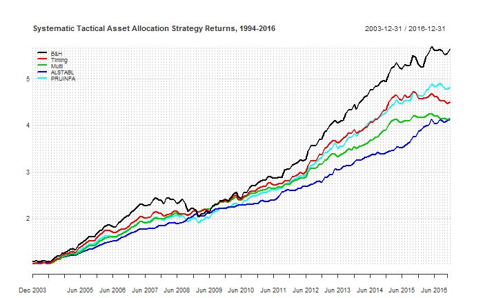

```r
annualfee <- 0.01
fees <- ((1 + annualfee)^(1/12))-1
Returns <- cbind.xts(AllAssets.xts$SAMAF.BuyandHold.ret,
                     AllAssets.xts$SAMAF.Timing.ret-fees,
                     AllAssets.xts$SAMAF.Avg.Combo.Band.ret-fees,
                     AllAssets2.ret$ALSTABL,
                     AllAssets2.ret$PRUINFA)[SubsetPeriod.Reporting]
colnames(Returns) <- c("B&H","Timing","Multi","ALSTABL","PRUINFA")
chart.CumReturns(Returns, wealth.index = TRUE,
  main = "Systematic Tactical Asset Allocation Strategy Returns, 1994-2016",
  #colorset = c(4,2,3,5,6),
  legend.loc = "topleft",
  date.format = "%Y", ylab = "", ylog = TRUE)
```

[output not shown]

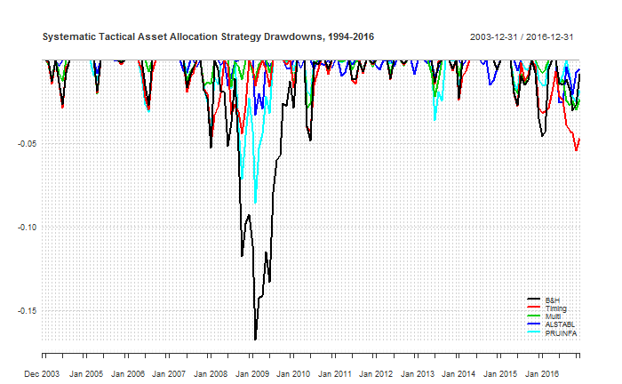

```r
chart.Drawdown(Returns,#[,-1], to exclude B&H
  main = "Systematic Tactical Asset Allocation Strategy Drawdowns, 1994-2016",
  date.format = "%Y",
  #colorset = c(4,2,3,5,6),
  ylab = "Drawdown", legend.loc = "bottomright", major.ticks = "years",  minor.ticks = FALSE)
```

```r
TimeInMarket <- c(nrow(AllAssets.xts[SubsetPeriod.Reporting]),
                  sum(AllAssets.xts$WMAF.Timing.signal[SubsetPeriod.Reporting]),
                  sum(AllAssets.xts$WMAF.Avg.Combo.Band.signal[SubsetPeriod.Reporting]),
                  nrow(AllAssets.xts[SubsetPeriod.Reporting]),
                  sum(AllAssets.xts$SAMAF.Timing.signal[SubsetPeriod.Reporting]),
                  sum(AllAssets.xts$SAMAF.Avg.Combo.Band.signal[SubsetPeriod.Reporting]))/nrow(AllAssets.xts[SubsetPeriod.Reporting])
FullStats <- rbind(Return.annualized(Returns,scale = 12)*FormatMultiplier,
                   StdDev.annualized(Returns,scale = 12)*FormatMultiplier,
                   skewness(Returns),
                   kurtosis(Returns),
                   100*c(Return.annualized(AllAssets.ret$SACPI[SubsetPeriod.Reporting],scale = 12)),
                   TimeInMarket*FormatMultiplier,
                   apply(Returns, 2, function(x) length(x[x>0]))/nrow(Returns)*FormatMultiplier,
                   apply(Returns, 2, function(x) max(x, na.rm = TRUE))*FormatMultiplier,
                   apply(Returns, 2, function(x) min(x, na.rm = TRUE))*FormatMultiplier,
                   maxDrawdown(Returns,scale = 12,invert = FALSE)*FormatMultiplier,
                   -maxDrawdown(Returns,scale = 12,invert = FALSE)/Return.annualized(Returns,scale = 12),
                   SharpeRatio.annualized(Returns,Rf = AllAssets.ret$TBILLS[SubsetPeriod.Reporting]),
                   SortinoRatio(Returns, scale = 12), #what MAR?
                   CalmarRatio(Returns, scale = 12),
                   UlcerIndex(Returns)*FormatMultiplier)
colnames(FullStats) <- colnames(Returns)
PerformanceMeasures <- c("CAGR","Volatility","Skew","Kurtosis","Inflation CAGR","% in the Market","% positive Months","Best Month","Worst Month","Max Drawdown","Max Drawdown / CAGR",paste("Sharpe Ratio (",round(100*Return.annualized(Return.calculate(TBILLS)[SubsetPeriod.Reporting]),2),"%)", sep = ""),"Sortino Ratio","MAR Ratio","Ulcer Index")
rownames(FullStats) <- PerformanceMeasures
round(FullStats,2)
```

|  | B&H | Timing | Multi | ALSTABL | PRUINFA |
| --- | --- | --- | --- | --- | --- |
| CAGR | 14.15 | 12.19 | 11.50 | 11.43 | 12.76 |
| Volatility | 7.99 | 6.27 | 4.66 | 4.35 | 5.78 |
| Skew | -0.29 | 0.06 | -0.03 | 0.14 | -0.42 |
| Kurtosis | 0.69 | -0.01 | -0.40 | 0.71 | 0.66 |
| Inflation CAGR | 5.77 | 5.77 | 5.77 | 5.77 | 5.77 |
| % in the Market | 100.00 | 81.56 | 63.20 | 100.00 | 81.85 |
| % positive Months | 70.06 | 70.06 | 74.52 | 77.07 | 75.80 |
| Best Month | 6.95 | 6.87 | 4.29 | 4.66 | 5.43 |
| Worst Month | -6.71 | -4.08 | -2.87 | -3.30 | -4.51 |
| Max Drawdown | -16.77 | -5.41 | -2.99 | -3.30 | -8.59 |

[output cut: 5 more lines]

```r
write.table(round(FullStats,4), "clipboard", sep="\t", col.names=NA)
write.table(round(Returns,5), "clipboard", sep="\t", col.names=NA)
```

```r
chart.RollingPerformance(Returns[,1:3],
                         width = 12,
                         main = "WMAF Strategy Rolling 12-month Annualised Return",
                         legend.loc = "topleft")

chart.RollingPerformance(Returns$'WMAF Multi'-Returns$'WMAF B&H',
                         width = 12,
                         main = "WMAF Multi less WMAF B&H Rolling 12-month Annualised Return"
                         )

chart.RollingPerformance(Returns[,4:6],
                         width = 12,
                         main = "SAMAF Strategy Rolling 12-month Annualised Return",
                         legend.loc = "topleft")


chart.RollingPerformance(Returns$'SAMAF Multi'-Returns$'SAMAF B&H',
                         width = 12,
                         main = "SAMAF Multi less SAMAF B&H Rolling 12-month Annualised Return"
                         )

table.CalendarReturns(Returns$'SAMAF Multi'["1994::2016"])[13]
```

#### Example of benefit of averaging timing signals

```r
#for calculating the sharpe ratio later
Rf.ret <- Return.calculate(TBILLYIELDS)[-1,]
Rf.ret <- Rf.ret[SubsetPeriod.Reporting]

#Get Returns
Returns <- cbind.xts(AllAssets.xts$MSCIWORLD.ret,
                     AllAssets.xts$MSCIWORLD.2m.timingret,
                     AllAssets.xts$MSCIWORLD.5m.timingret,
                     AllAssets.xts$MSCIWORLD.10m.timingret,
                     AllAssets.xts$MSCIWORLD.avg.timingret)[SubsetPeriod.Reporting]

#Time in market
TimeInMarket <- c(nrow(AllAssets.xts[SubsetPeriod.Reporting]),
  sum(AllAssets.xts$MSCIWORLD.2m.signal[SubsetPeriod.Reporting]),
  sum(AllAssets.xts$MSCIWORLD.5m.signal[SubsetPeriod.Reporting]),
  sum(AllAssets.xts$MSCIWORLD.10m.signal[SubsetPeriod.Reporting]),
  sum(AllAssets.xts$MSCIWORLD.avg.signal[SubsetPeriod.Reporting]))/nrow(AllAssets.xts[SubsetPeriod.Reporting])

FormatMultiplier <- 100

FullStats <- rbind(Return.annualized(Returns,scale = 12)*FormatMultiplier,
                   StdDev.annualized(Returns,scale = 12)*FormatMultiplier,
                   skewness(Returns),
                   kurtosis(Returns),
                   100*c(Return.annualized(AllAssets.ret$SACPI[SubsetPeriod.Reporting],scale = 12)),
                   TimeInMarket*FormatMultiplier,
                   apply(Returns, 2, function(x) length(x[x>0]))/nrow(Returns)*FormatMultiplier,
                   apply(Returns, 2, function(x) max(x, na.rm = TRUE))*FormatMultiplier,
                   apply(Returns, 2, function(x) min(x, na.rm = TRUE))*FormatMultiplier,
                   maxDrawdown(Returns,scale = 12,invert = FALSE)*FormatMultiplier,
                   -maxDrawdown(Returns,scale = 12,invert = FALSE)/Return.annualized(Returns,scale = 12),
                   SharpeRatio.annualized(Returns,Rf = AllAssets.ret$TBILLS[SubsetPeriod.Reporting]),
                   SortinoRatio(Returns, scale = 12), #what MAR?
                   CalmarRatio(Returns, scale = 12),
                   UlcerIndex(Returns)*FormatMultiplier)

colnames(FullStats) <- c("B&H","2M Timing","5M Timing","10M Timing","Avg Timing")

rownames(FullStats) <- c("CAGR","Volatility","Skew","Kurtosis","Inflation CAGR","% in the Market","% positive Months","Best Month","Worst Month","Max Drawdown","Max Drawdown / CAGR",paste("Sharpe Ratio (",round(100*Return.annualized(Return.calculate(TBILLS)[SubsetPeriod.Reporting]),2),"%)", sep = ""),"Sortino Ratio","MAR Ratio","Ulcer Index")

round(FullStats,2)
write.table(round(FullStats,4), "clipboard", sep="\t", col.names=NA)
#how do i get a distribution chart to check skew/kurtosis
```

### compare delayed to normal to see benefits of avoiding whipsaws

```r
#for calculating the sharpe ratio later
Rf.ret <- Return.calculate(TBILLYIELDS)[-1,]
Rf.ret <- Rf.ret[SubsetPeriod.Reporting]

Returns <- cbind.xts(AllAssets.xts$JALSH.10m.timingret,
                     AllAssets.xts$JALSH.10m.timingret.delayed)[SubsetPeriod.Reporting]

#Time in market
TimeInMarket <- c(sum(AllAssets.xts$JALSH.10m.signal[SubsetPeriod.Reporting]),
  sum(AllAssets.xts$JALSH.10m.signal.delayed[SubsetPeriod.Reporting]))/nrow(AllAssets.xts[SubsetPeriod.Reporting])

FormatMultiplier <- 100

FullStats <- rbind(Return.annualized(Returns,scale = 12)*FormatMultiplier,
                   StdDev.annualized(Returns,scale = 12)*FormatMultiplier,
                   skewness(Returns),
                   kurtosis(Returns),
                   100*c(Return.annualized(AllAssets.ret$SACPI[SubsetPeriod.Reporting],scale = 12)),
                   TimeInMarket*FormatMultiplier,
                   apply(Returns, 2, function(x) length(x[x>0]))/nrow(Returns)*FormatMultiplier,
                   apply(Returns, 2, function(x) max(x, na.rm = TRUE))*FormatMultiplier,
                   apply(Returns, 2, function(x) min(x, na.rm = TRUE))*FormatMultiplier,
                   maxDrawdown(Returns,scale = 12,invert = FALSE)*FormatMultiplier,
                   -maxDrawdown(Returns,scale = 12,invert = FALSE)/Return.annualized(Returns,scale = 12),
                   SharpeRatio.annualized(Returns,Rf = AllAssets.ret$TBILLS[SubsetPeriod.Reporting]),
                   SortinoRatio(Returns, scale = 12), #what MAR?
                   CalmarRatio(Returns, scale = 12),
                   UlcerIndex(Returns)*FormatMultiplier)

colnames(FullStats) <- c("Timing","Delayed Timing")

rownames(FullStats) <- c("CAGR","Volatility","Skew","Kurtosis","Inflation CAGR","% in the Market","% positive Months","Best Month","Worst Month","Max Drawdown","Max Drawdown / CAGR",paste("Sharpe Ratio (",round(100*Return.annualized(Return.calculate(TBILLS)[SubsetPeriod.Reporting]),2),"%)", sep = ""),"Sortino Ratio","MAR Ratio","Ulcer Index")

round(FullStats,2)
write.table(round(FullStats,4), "clipboard", sep="\t", col.names=NA)
#how do i get a distribution chart to check skew/kurtosis
```

```r
chart.RollingPerformance(Returns$"10m Timing Delayed"-Returns$"10m Timing",
                         width = 3,
                         main = "Rolling Perf"
                         )
```

```r
chart_Series(Cl(SA10YR),
  name = paste("SA10YR vs 10 Month Simple Moving Average",sep = ""),
  theme=myChart_Theme,
  type = "line",
  subset = "1983::1986-06",
  TA = 'add_SMA(n=SMAperiod, on=1, col="red")'
  )
```

so better sharpe? [confirm calc method/fix interest rate… should i calc manually?] and less maxdd whats kurtosis, information ratio, skew. ask what metrics rad, mb and emyln use… run on longer dater in asset allocation ratios

last 12 months, 3 years, etc returns

rolling returns

to do:

- how to calculate dailyreturns with NA
- check returns make sense - effect of zar?
- compare to US / JPY
- create RF to get 2002 in

To do: SA assets Daily drawdowns monthly returns table Relative performance / rolling perofrmance / alpha 10 worst periods / 10 best periods do different averages improve SA - check robustness of averages….